# Measurement-Frequency Project Summary Dashboard

This notebook is an exploratory dashboard of the measurement-frequency experiments. It is not a paper-figure notebook and it does not rerun discovery, checkpoint selection, normalizer selection, prediction generation, or patient bootstrap logic.

The source notebooks are the authority for scientific definitions and calculations:

- `visualize_exp1_frequency.ipynb`
- `visualize_exp2a_horizon.ipynb`
- `visualize_exp2b_matched_count.ipynb`
- `visualize_exp3_frequency_shift.ipynb`
- `visualize_exp3_grud_frequency_shift.ipynb`
- `visualize_utils.py`

This summary consumes stable CSV exports written by those notebooks. If a source notebook has not yet been rerun after the export cells were added, its section is labeled `NOT AVAILABLE`. Partial seed sets are shown as partial, not suppressed.

We report two complementary uncertainty estimates. The **Student-t CI across model seeds** varies the trained model: for each seed, we compute the paired performance difference between two conditions on the same test set, then form a Student-t CI over those seed-level differences. The test patients are fixed, while model initialization/training randomness varies. The **paired patient-level bootstrap CI** instead keeps the trained models fixed and repeatedly resamples patients with replacement. For each bootstrap sample, the paired performance difference is recomputed separately for every model seed using the same resampled patients, then averaged across seeds; the 2.5th and 97.5th percentiles of these bootstrap mean differences form the CI. Thus, this interval reflects uncertainty from the finite test population rather than variability from retraining the model.

visualize_exp3_grud_frequency_shift.ipynb optionally consumes the LSTM Exp3 visualizer output from visualize_exp3_frequency_shift.ipynb, for summary

## 0. Imports

```python
from pathlib import Path
import ast
import html
import os

import numpy as np
import pandas as pd
from scipy.stats import t
from IPython.display import HTML, Image, display

if not hasattr(pd, "isna"):
    pd.isna = pd.isnull
if not hasattr(pd, "notna"):
    pd.notna = pd.notnull

pd.set_option("display.max_columns", 120)
pd.set_option("display.max_rows", 120)

SUMMARY_MODE = os.environ.get("SUMMARY_MODE", "full").strip().lower()
if SUMMARY_MODE not in {"full", "figures"}:
    raise ValueError("SUMMARY_MODE must be 'full' or 'figures'")
SHOW_TABLES = SUMMARY_MODE == "full"
SUMMARY_TABLE_METADATA_KEY = "summary_table"


def maybe_display_table(obj, always_show=False):
    if SHOW_TABLES or always_show:
        display(obj, metadata={SUMMARY_TABLE_METADATA_KEY: {"always_show": bool(always_show)}})


HERE = Path.cwd()
REPO_DIR = HERE.parent if HERE.name == "visualizers" else HERE
VIS_DIR = REPO_DIR / "visualizers"

PROJECT_DATA_ROOT = Path(os.environ.get(
    "MEAS_FREQ_DATA_ROOT",
    "/heinz-georgenas/users/mingzhul/Simultaneous-EHR/data/physionet.org/files/mimiciv/1.0/russo",
))
IHM_PLOTS = PROJECT_DATA_ROOT / "results/in-hospital-mortality/plots"
DECOMP_PLOTS = PROJECT_DATA_ROOT / "results/decompensation/plots"
FH_PLOTS = PROJECT_DATA_ROOT / "results/fixed_horizon_icu_exit/plots"

EXPECTED_SEEDS = set(range(5))
METRICS = ["auprc", "auroc", "brier"]

EXPORTS = {
    "exp1_runs": IHM_PLOTS / "experiment1_runs.csv",
    "exp1_val_auprc_summary": IHM_PLOTS / "experiment1_validation_auprc_summary.csv",
    "exp1_val_auroc_summary": IHM_PLOTS / "experiment1_validation_auroc_summary.csv",
    "exp1_test_auprc_summary": IHM_PLOTS / "experiment1_test_auprc_summary.csv",
    "exp1_test_auroc_summary": IHM_PLOTS / "experiment1_test_auroc_summary.csv",
    "exp1_test_drops": IHM_PLOTS / "experiment1_test_degradation_seed_level.csv",
    "exp1_degradation_unmatched": IHM_PLOTS / "experiment1_test_degradation_unmatched.csv",
    "exp1_auprc_drop_summary": IHM_PLOTS / "experiment1_test_auprc_degradation_summary.csv",
    "exp1_auroc_drop_summary": IHM_PLOTS / "experiment1_test_auroc_degradation_summary.csv",
    "exp1_test_degradation_summary": IHM_PLOTS / "experiment1_test_degradation_relative_to_1h_summary.csv",

    "exp1_decomp_runs": DECOMP_PLOTS / "experiment1_runs.csv",
    "exp1_decomp_val_auprc_summary": DECOMP_PLOTS / "experiment1_validation_auprc_summary.csv",
    "exp1_decomp_val_auroc_summary": DECOMP_PLOTS / "experiment1_validation_auroc_summary.csv",
    "exp1_decomp_test_auprc_summary": DECOMP_PLOTS / "experiment1_test_auprc_summary.csv",
    "exp1_decomp_test_auroc_summary": DECOMP_PLOTS / "experiment1_test_auroc_summary.csv",
    "exp1_decomp_test_drops": DECOMP_PLOTS / "experiment1_test_degradation_seed_level.csv",
    "exp1_decomp_degradation_unmatched": DECOMP_PLOTS / "experiment1_test_degradation_unmatched.csv",
    "exp1_decomp_auprc_drop_summary": DECOMP_PLOTS / "experiment1_test_auprc_degradation_summary.csv",
    "exp1_decomp_auroc_drop_summary": DECOMP_PLOTS / "experiment1_test_auroc_degradation_summary.csv",
    "exp1_decomp_test_degradation_summary": DECOMP_PLOTS / "experiment1_test_degradation_relative_to_1h_summary.csv",

    "exp2a_val_runs": FH_PLOTS / "experiment2a_validation_runs.csv",
    "exp2a_val_auprc_summary": FH_PLOTS / "experiment2a_validation_auprc_summary.csv",
    "exp2a_val_auroc_summary": FH_PLOTS / "experiment2a_validation_auroc_summary.csv",
    "exp2a_val_auprc_drop_summary": FH_PLOTS / "experiment2a_validation_auprc_degradation_summary.csv",
    "exp2a_val_auroc_drop_summary": FH_PLOTS / "experiment2a_validation_auroc_degradation_summary.csv",
    "exp2a_test_runs": FH_PLOTS / "experiment2a_test_runs.csv",
    "exp2a_test_auprc_summary": FH_PLOTS / "experiment2a_test_auprc_summary.csv",
    "exp2a_test_auroc_summary": FH_PLOTS / "experiment2a_test_auroc_summary.csv",
    "exp2a_test_auprc_drop_summary": FH_PLOTS / "experiment2a_test_auprc_degradation_summary.csv",
    "exp2a_test_auroc_drop_summary": FH_PLOTS / "experiment2a_test_auroc_degradation_summary.csv",
    "exp2a_bootstrap": FH_PLOTS / "experiment2a_seed_level_patient_bootstrap.csv",
    "exp2a_bootstrap_summary": FH_PLOTS / "experiment2a_across_seed_patient_bootstrap_summary.csv",

    "exp2b_run_results": FH_PLOTS / "experiment2b_included_prediction_results.csv",
    "exp2b_condition_summary": FH_PLOTS / "experiment2b_condition_summary.csv",
    "exp2b_seed_level_contrasts": FH_PLOTS / "experiment2b_seed_level_patient_bootstrap_contrasts.csv",
    "exp2b_across_seed_summary": FH_PLOTS / "experiment2b_across_seed_contrast_summary.csv",
    "exp2b_input_information_summary": FH_PLOTS / "experiment2b_input_information_summary.csv",
    "exp2b_input_information_channel_retention": FH_PLOTS / "experiment2b_input_information_channel_retention.csv",

    "exp3_lstm_run_results": FH_PLOTS / "experiment3_lstm_condition_run_results.csv",
    "exp3_lstm_absolute_summary": FH_PLOTS / "experiment3_lstm_absolute_summary.csv",
    "exp3_lstm_information_summary": FH_PLOTS / "experiment3_lstm_information_effects_summary.csv",
    "exp3a_input_information_summary": FH_PLOTS / "experiment3a_input_information_summary.csv",
    "exp3a_input_information_channel_retention": FH_PLOTS / "experiment3a_input_information_channel_retention.csv",
    "exp3_lstm_structured_shift_summary": FH_PLOTS / "experiment3_lstm_structured_shift_summary.csv",
    "exp3_lstm_normalizer_control_summary": FH_PLOTS / "experiment3_lstm_normalizer_control_summary.csv",
    "exp3_lstm_random_shift_summary": FH_PLOTS / "experiment3_lstm_random_shift_summary.csv",
    "exp3_lstm_horizon_replication_summary": FH_PLOTS / "experiment3_lstm_horizon_replication_summary.csv",
    "exp3e_lstm_raw_run_results": FH_PLOTS / "experiment3e_lstm_raw_condition_run_results.csv",
    "exp3e_lstm_raw_absolute_summary": FH_PLOTS / "experiment3e_lstm_raw_absolute_summary.csv",
    "exp3e_raw_representation_characterization_summary": FH_PLOTS / "experiment3e_raw_representation_characterization_summary.csv",
    "exp3e_raw_representation_channel_retention": FH_PLOTS / "experiment3e_raw_representation_channel_retention.csv",
    "exp3e_lstm_raw_shift_seed_level": FH_PLOTS / "experiment3e_lstm_raw_shift_seed_level.csv",
    "exp3e_lstm_raw_shift_summary": FH_PLOTS / "experiment3e_lstm_raw_shift_summary.csv",
    "exp3_lstm_grid_vs_raw_shift_seed_level": FH_PLOTS / "experiment3_lstm_grid_vs_raw_shift_seed_level.csv",
    "exp3_lstm_grid_vs_raw_shift_summary": FH_PLOTS / "experiment3_lstm_grid_vs_raw_shift_summary.csv",
    "exp3e_lstm_grid_matched_vs_raw_dense_summary": FH_PLOTS / "experiment3e_lstm_grid_matched_vs_raw_dense_summary.csv",
    "exp3_lstm_combined_key_contrast_summary": FH_PLOTS / "experiment3_lstm_combined_key_contrast_summary.csv",
    "exp3_lstm_final_contrast_coverage": FH_PLOTS / "experiment3_lstm_final_contrast_coverage.csv",

    "exp3_grud_run_results": FH_PLOTS / "experiment3_grud_condition_run_results.csv",
    "exp3_grud_across_seed_summary": FH_PLOTS / "experiment3_grud_across_seed_summary.csv",
    "exp3_grud_structured_shift_summary": FH_PLOTS / "experiment3_grud_structured_shift_summary.csv",
    "exp3_grud_normalizer_control_summary": FH_PLOTS / "experiment3_grud_normalizer_control_summary.csv",
    "exp3_grud_random_shift_summary": FH_PLOTS / "experiment3_grud_random_shift_summary.csv",
    "exp3_grud_horizon_replication_summary": FH_PLOTS / "experiment3_grud_horizon_replication_summary.csv",
    "exp3_grud_combined_key_contrast_summary": FH_PLOTS / "experiment3_grud_combined_key_contrast_summary.csv",
    "exp3e_grud_raw_run_results": FH_PLOTS / "experiment3e_grud_raw_run_results.csv",
    "exp3e_grud_raw_absolute_summary": FH_PLOTS / "experiment3e_grud_raw_absolute_summary.csv",
    "exp3e_grud_raw_shift_seed_level": FH_PLOTS / "experiment3e_grud_raw_shift_seed_level.csv",
    "exp3e_grud_raw_shift_summary": FH_PLOTS / "experiment3e_grud_raw_shift_summary.csv",
    "exp3_grud_grid_vs_raw_shift_seed_level": FH_PLOTS / "experiment3_grud_grid_vs_raw_shift_seed_level.csv",
    "exp3_grud_grid_vs_raw_shift_summary": FH_PLOTS / "experiment3_grud_grid_vs_raw_shift_summary.csv",
    "exp3_grud_cross_experiment_summary": FH_PLOTS / "experiment3_grud_cross_experiment_mismatch_summary.csv",
    "exp3_grud_final_status": FH_PLOTS / "experiment3_grud_final_status.csv",
    "exp3_grud_final_contrast_coverage": FH_PLOTS / "experiment3_grud_final_contrast_coverage.csv",
}

DATA = {}
load_rows = []
for key, path in EXPORTS.items():
    if path.exists():
        try:
            df = pd.read_csv(path)
        except pd.errors.EmptyDataError:
            df = pd.DataFrame()
            DATA[key] = df
            load_rows.append({"key": key, "status": "EMPTY", "rows": 0, "path": str(path)})
            continue
        DATA[key] = df
        load_rows.append({"key": key, "status": "LOADED", "rows": len(df), "path": str(path)})
    else:
        DATA[key] = pd.DataFrame()
        load_rows.append({"key": key, "status": "NOT AVAILABLE", "rows": 0, "path": str(path)})

load_status = pd.DataFrame(load_rows)
maybe_display_table(load_status)
```

```python
def parse_listish(value):
    if isinstance(value, list):
        return value
    if pd.isna(value):
        return []
    text = str(value)
    try:
        parsed = ast.literal_eval(text)
        return parsed if isinstance(parsed, list) else [parsed]
    except Exception:
        return [x.strip() for x in text.strip("[]").split(",") if x.strip()]


def title_with_bs(title, batch_size=8):
    return "{} (bs={})".format(title, int(batch_size))

def batch_size_for_task(task):
    return 320 if str(task).lower().startswith("decomp") else 8

def exp1_summary_label(label):
    return "{} (bs={})".format(label, batch_size_for_task(label))


def status_from_n(n, expected=5):
    if pd.isna(n) or int(n) == 0:
        return "NOT AVAILABLE"
    return "COMPLETE" if int(n) >= int(expected) else "PARTIAL"


def add_status(df, n_col="n", expected=5):
    if df is None or len(df) == 0:
        return pd.DataFrame()
    out = df.copy()
    if n_col in out.columns:
        out["expected_seeds"] = out.get("expected_seeds", expected)
        out["status"] = out[n_col].apply(lambda x: status_from_n(x, expected))
    elif "n_seeds" in out.columns:
        out["expected_seeds"] = out.get("expected_seeds", expected)
        out["status"] = out["n_seeds"].apply(lambda x: status_from_n(x, expected))
    elif "complete_seed_set" in out.columns:
        out["status"] = out["complete_seed_set"].map(lambda x: "COMPLETE" if bool(x) else "PARTIAL")
    return out


def select_cols(df, cols):
    return df[[c for c in cols if c in df.columns]] if len(df) else df


def show_table(title, df, cols=None, max_rows=120, always_show=False):
    if not SHOW_TABLES and not always_show:
        return
    if df is None or len(df) == 0:
        display(HTML("<section class='summary-table-output'><h4>{}</h4><p>NOT AVAILABLE</p></section>".format(html.escape(title))), metadata={SUMMARY_TABLE_METADATA_KEY: {"always_show": bool(always_show)}})
        return
    view = select_cols(df, cols) if cols else df
    more = "<p>... {} more rows</p>".format(len(view) - max_rows) if len(view) > max_rows else ""
    display(HTML("<section class='summary-table-output'><h4>{}</h4>{}{}</section>".format(html.escape(title), view.head(max_rows).to_html(), more)), metadata={SUMMARY_TABLE_METADATA_KEY: {"always_show": bool(always_show)}})


SOURCE_NOTEBOOKS = {
    "exp1": "visualize_exp1_frequency.ipynb",
    "exp2a": "visualize_exp2a_horizon.ipynb",
    "exp2bc": "visualize_exp2b_matched_count.ipynb",
    "exp3_lstm": "visualize_exp3_frequency_shift.ipynb",
    "exp3_grud": "visualize_exp3_grud_frequency_shift.ipynb",
}


def discover_saved_png_names(notebook_filename):
    path = VIS_DIR / notebook_filename
    if not path.exists():
        return []
    import json as _json
    with open(str(path)) as f:
        nb = _json.load(f)
    names = []
    for cell in nb.get("cells", []):
        source = "".join(cell.get("source", []))
        for pattern in [r'"([^"]+\.png)"', r"'([^']+\.png)'"]:
            for name in __import__("re").findall(pattern, source):
                if name not in names:
                    names.append(name)
    return names


SOURCE_PNG_NAMES = {
    key: discover_saved_png_names(filename)
    for key, filename in SOURCE_NOTEBOOKS.items()
}


def _template_to_regex(template):
    import re
    return "^" + re.escape(template).replace(r"\{\}", r".+") + "$"


def filename_declared_by_source(source_key, filename):
    import re
    names = SOURCE_PNG_NAMES.get(source_key, [])
    if filename in names:
        return True
    return any(re.match(_template_to_regex(name), filename) for name in names if "{}" in name)


def show_saved_plot(path, title=None):
    path = Path(path)
    if title:
        print("\n" + title)
        print("=" * len(title))
    if path.exists():
        display(Image(filename=str(path)))
    else:
        print("NOT AVAILABLE:", path)


def show_source_plot(source_key, output_dir, filename, title=None):
    if not filename_declared_by_source(source_key, filename):
        print("\n{}".format(title or filename))
        print("=" * len(str(title or filename)))
        print("NOT DECLARED BY SOURCE NOTEBOOK:", filename)
        return
    show_saved_plot(Path(output_dir) / filename, title or filename)


def show_source_plot_group(title, source_key, output_dir, filenames):
    print("\n" + title)
    print("=" * len(title))
    filenames = list(filenames)
    if not filenames:
        print("NOT AVAILABLE")
        return
    for filename in filenames:
        show_source_plot(source_key, output_dir, filename, filename)


def show_paired_source_plots(title, lstm_filename, grud_filename, width_percent=48,
                             lstm_label="LSTM", grud_label="GRU-D"):
    print("\n" + title)
    print("=" * len(title))
    pairs = [(lstm_label, "exp3_lstm", lstm_filename), (grud_label, "exp3_grud", grud_filename)]
    missing = []
    undeclared = []
    ready = []
    cells = []
    for label, source_key, filename in pairs:
        if not filename_declared_by_source(source_key, filename):
            undeclared.append(filename)
        path = FH_PLOTS / filename
        if not path.exists():
            missing.append(str(path))
        ready.append((label, path))
    if undeclared:
        print("NOT DECLARED BY SOURCE NOTEBOOK:", undeclared)
    if missing:
        print("NOT AVAILABLE:", missing)
    if undeclared or missing:
        return
    import base64 as _base64
    import html as _html
    for label, path in ready:
        src = "data:…" + _base64.b64encode(path.read_bytes()).decode("ascii")
        cells.append(
            "<td style='width:{w}%; vertical-align:top; padding-right:12px;'>"
            "<div style='font-weight:600; margin-bottom:4px;'>{label}</div>"
            "<img src='{src}' style='max-width:100%; height:auto;'>"
            "</td>".format(w=width_percent, label=_html.escape(label), src=src)
        )
    display(HTML("<table style='width:100%;'><tr>{}</tr></table>".format("".join(cells))))


def numeric_values(df, col):
    if df is None or len(df) == 0 or col not in df.columns:
        return []
    return sorted(pd.to_numeric(df[col], errors="coerce").dropna().astype(int).unique().tolist())


def exp2b_condition_plot_filenames():
    df = DATA["exp2b_condition_summary"]
    if df is None or len(df) == 0:
        return []
    out = []
    for r in numeric_values(df, "r"):
        for metric in ["test_auroc", "test_auprc", "test_brier"]:
            if "metric" in df.columns and len(df[(pd.to_numeric(df["r"], errors="coerce") == r) & df["metric"].astype(str).eq(metric)]):
                out.append("experiment2b_r{}_{}_by_condition_ci95.png".format(r, metric))
    return out


def exp2b_primary_contrast_plot_filenames():
    df = DATA["exp2b_across_seed_summary"]
    if df is None or len(df) == 0:
        return []
    out = []
    flag_col = "main_contrast" if "main_contrast" in df.columns else "primary"
    primary = df[df.get(flag_col, pd.Series(dtype=bool)).astype(bool)] if flag_col in df.columns else df
    for r in numeric_values(primary, "r"):
        for metric in METRICS:
            if "metric" in primary.columns and len(primary[(pd.to_numeric(primary["r"], errors="coerce") == r) & primary["metric"].astype(str).eq(metric)]):
                out.append("experiment2b_r{}_{}_primary_contrasts_bootstrap_ci95.png".format(r, metric))
    return out


def exp2c_severity_plot_filenames():
    df = DATA["exp2b_across_seed_summary"]
    if df is None or len(df) == 0:
        return []
    out = []
    flag_col = "main_contrast" if "main_contrast" in df.columns else "primary"
    primary = df[df.get(flag_col, pd.Series(dtype=bool)).astype(bool)] if flag_col in df.columns else df
    for metric in METRICS:
        sub = primary[primary.get("metric", pd.Series(dtype=str)).astype(str).eq(metric)] if "metric" in primary.columns else pd.DataFrame()
        if len(numeric_values(sub, "r")) >= 2:
            out.append("experiment2c_{}_mechanism_vs_r_bootstrap_ci95.png".format(metric))
    return out
```

```python
def groupby_keep_missing(df, group_cols):
    work = df.copy()
    sentinel = "__MISSING_GROUP_VALUE__"
    for col in group_cols:
        if col not in work.columns:
            work[col] = sentinel
        else:
            work[col] = work[col].where(~work[col].isnull(), sentinel)
    for keys, group in work.groupby(group_cols):
        keys = keys if isinstance(keys, tuple) else (keys,)
        keys = tuple(np.nan if key == sentinel else key for key in keys)
        yield keys, group


def coverage_from_run_df(df, experiment, group_cols, seed_col, extra=None):
    if df is None or len(df) == 0 or seed_col not in df.columns:
        row = {"experiment": experiment, "status": "NOT AVAILABLE", "n": 0, "expected_seeds": 5, "missing_seeds": sorted(EXPECTED_SEEDS)}
        if extra:
            row.update(extra)
        return [row]
    rows = []
    for keys, g in groupby_keep_missing(df, group_cols):
        observed = set(pd.to_numeric(g[seed_col], errors="coerce").dropna().astype(int))
        row = dict(zip(group_cols, keys))
        row.update({
            "experiment": experiment,
            "observed_seeds": sorted(observed),
            "expected_seeds": 5,
            "n": len(observed),
            "missing_seeds": sorted(EXPECTED_SEEDS - observed),
            "status": status_from_n(len(observed)),
        })
        if extra:
            row.update(extra)
        rows.append(row)
    return rows


def exp3e_raw_coverage_df(df):
    if df is None or len(df) == 0:
        return df
    out = df.copy()
    out["r"] = pd.to_numeric(out["target_r"], errors="coerce") if "target_r" in out.columns else np.nan
    return out

coverage_rows = []
for _key, _task in [
    ("exp1_runs", "in-hospital mortality"),
    ("exp1_decomp_runs", "decompensation"),
]:
    coverage_rows += coverage_from_run_df(DATA[_key], "Exp1", ["condition", "timestep"], "seed", {"task": _task, "model": "LSTM", "batch_size": batch_size_for_task(_task), "comparison": "absolute performance"})
coverage_rows += coverage_from_run_df(DATA["exp2a_test_runs"], "Exp2A", ["horizon", "timestep"], "seed", {"task": "fixed-horizon ICU outcome", "model": "LSTM", "batch_size": 8, "comparison": "1h vs coarser resolution"})
coverage_rows += coverage_from_run_df(DATA["exp2b_run_results"], "Exp2B/C", ["horizon", "r", "condition"], "model_seed", {"task": "fixed-horizon ICU outcome", "model": "LSTM", "batch_size": 8, "comparison": "A/B/C/D mechanism"})
coverage_rows += coverage_from_run_df(DATA["exp3_lstm_run_results"], "Exp3 LSTM", ["experiment", "horizon", "target_r", "condition", "normalizer_regime"], "model_seed", {"task": "fixed-horizon ICU outcome", "model": "LSTM", "batch_size": 8, "comparison": "frequency-shift absolute condition"})
coverage_rows += coverage_from_run_df(DATA["exp3_grud_run_results"], "Exp3 GRU-D", ["experiment", "horizon", "target_r", "condition", "normalizer_regime"], "model_seed", {"task": "fixed-horizon ICU outcome", "model": "GRU-D", "batch_size": 8, "comparison": "frequency-shift absolute condition"})
coverage_rows += coverage_from_run_df(exp3e_raw_coverage_df(DATA["exp3e_lstm_raw_run_results"]), "Exp3E Raw", ["horizon", "r", "condition"], "model_seed", {"task": "fixed-horizon ICU outcome", "model": "Raw LSTM", "batch_size": 8, "comparison": "raw representation absolute condition"})

coverage_dashboard = pd.DataFrame(coverage_rows)
coverage_cols = ["experiment", "task", "model", "batch_size", "horizon", "timestep", "target_r", "r", "condition", "normalizer_regime", "comparison", "observed_seeds", "expected_seeds", "n", "missing_seeds", "status"]
show_table("Experiment coverage dashboard", coverage_dashboard, coverage_cols, max_rows=300)
```

## 1. Experiment 1 - Does Measurement Frequency Matter?

### Scientific Question

Does prediction performance for in-hospital mortality deteriorate when EHR measurements are represented at coarser temporal resolutions?

### Experimental Design

Model: LSTM. Task: in-hospital mortality.

Prediction time/horizon: mortality prediction uses the first 48 hours of ICU data as input and predicts in-hospital mortality for the remainder of the hospitalization. Unlike Exp2A, this is not a fixed future horizon such as 12h or 24h; the outcome is whether the patient dies before hospital discharge.

Temporal resolution varies over the available timesteps, currently intended as 1h, 2h, 4h, 8h, 12h, and 24h. Training and test observation regimes match the same temporal resolution. Checkpoint selection is based on validation AUPRC; validation AUROC and test metrics are read at the same selected epoch.

### Quantity Being Measured

Absolute validation/test performance is `M(r,s)` for resolution `r` and model seed `s`. Degradation is `Delta(r,s) = M(1h,s) - M(r,s)`, computed within seed before summarizing across seeds.

Positive degradation means the coarser resolution performed worse than 1h. Zero means little or no difference. Negative means the coarser resolution performed better.

### Why This Comparison Is Informative

It tests whether reducing measurement frequency alone is associated with lower predictive performance, while preserving the source notebook's checkpoint and test-prediction provenance rules.

### Expected Evidence

If fine temporal information matters, degradation should become positive at sufficiently coarse resolutions. If frequency has little effect, performance and degradation should remain near flat. Non-monotonic behavior is possible and should be displayed.

### Caveats

Strict monotonic degradation is not required. Across-seed CIs are not paired patient-level tests. Partial seed sets have unstable across-seed uncertainty.

**Table/plot guide:** The next tables show validation and test AUPRC/AUROC means with 95% Student-t CIs across model seeds. Columns `mean`, `sd`, `sem`, and `ci95_*` are computed by the source notebook using model seeds as independent runs. `n` shows available seeds, so partial exports remain visible.

```
Exp1 absolute performance - IHM (bs=8)
======================================
```

```
Exp1 source figure: IHM (bs=8) absolute performance
===================================================
```

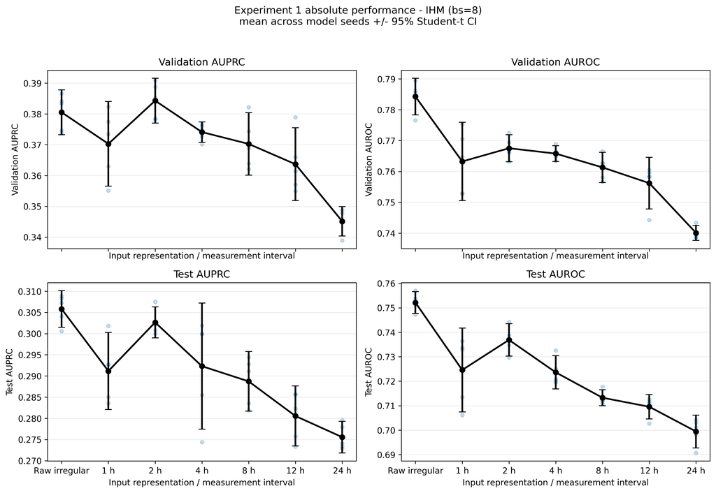

```
Exp1 absolute performance - Decompensation (bs=320)
===================================================
```

```
Exp1 source figure: Decompensation (bs=320) absolute performance
================================================================
```

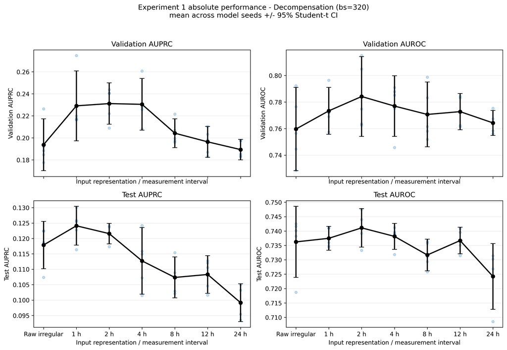

```python
EXP1_SUMMARY_TASKS = [
    ("IHM", "in-hospital mortality", "exp1", IHM_PLOTS),
    ("Decompensation", "decompensation", "exp1_decomp", DECOMP_PLOTS),
]

for label, task_name, prefix, plot_dir in EXP1_SUMMARY_TASKS:
    label_with_bs = exp1_summary_label(label)
    print("\nExp1 absolute performance - {}".format(label_with_bs))
    print("=" * len("Exp1 absolute performance - {}".format(label_with_bs)))
    for title, key in [
        ("validation AUPRC", "{}_val_auprc_summary".format(prefix)),
        ("validation AUROC", "{}_val_auroc_summary".format(prefix)),
        ("test AUPRC", "{}_test_auprc_summary".format(prefix)),
        ("test AUROC", "{}_test_auroc_summary".format(prefix)),
    ]:
        show_table("{} {}".format(label_with_bs, title), add_status(DATA[key]), ["task", "condition", "timestep", "mean", "sd", "sem", "ci95_low", "ci95_high", "n", "status"])
    show_source_plot(
        "exp1",
        plot_dir,
        "experiment1_absolute_performance_ci95.png",
        "Exp1 source figure: {} absolute performance".format(label_with_bs),
    )
```

**Degradation guide:** The degradation tables and plots show `1h - coarse`, computed within model seed and summarized with a 95% Student-t CI across seeds. Positive values mean degradation under coarser resolution. The interval is across model seeds, not a patient bootstrap interval. Partial status reflects how many paired seed-level drops are available.

```
Exp1 degradation relative to 1h - IHM (bs=8)
============================================
```

```
Exp1 source figure: IHM (bs=8) degradation relative to 1h
=========================================================
```

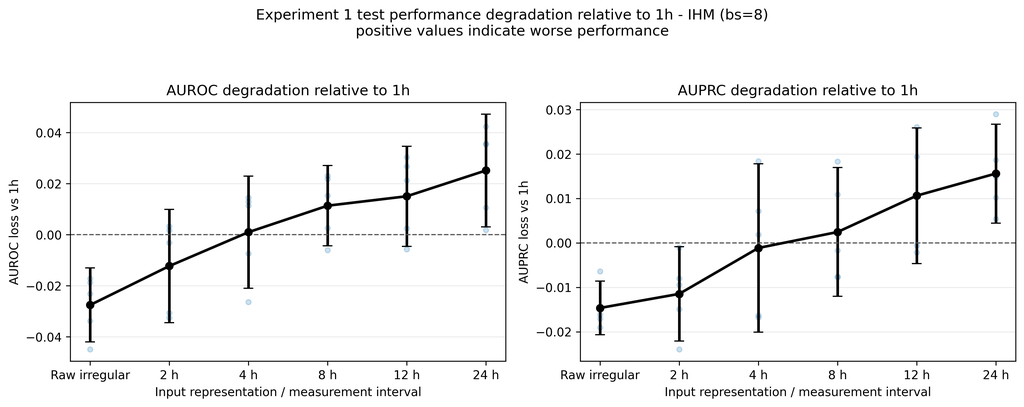

```
Exp1 degradation relative to 1h - Decompensation (bs=320)
=========================================================
```

```
Exp1 source figure: Decompensation (bs=320) degradation relative to 1h
======================================================================
```

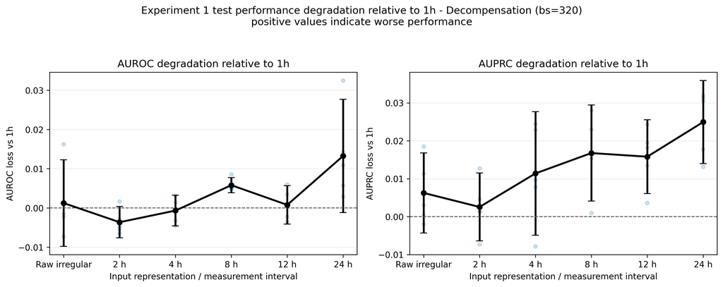

```python
for label, task_name, prefix, plot_dir in EXP1_SUMMARY_TASKS:
    exp1_auprc_drop = add_status(DATA["{}_auprc_drop_summary".format(prefix)])
    exp1_auroc_drop = add_status(DATA["{}_auroc_drop_summary".format(prefix)])
    exp1_degradation_summary = add_status(DATA["{}_test_degradation_summary".format(prefix)], n_col="n_seeds")
    exp1_degradation_unmatched = DATA["{}_degradation_unmatched".format(prefix)]
    label_with_bs = exp1_summary_label(label)
    print("\nExp1 degradation relative to 1h - {}".format(label_with_bs))
    print("=" * len("Exp1 degradation relative to 1h - {}".format(label_with_bs)))
    show_table("{} compact degradation relative to 1h".format(label_with_bs), exp1_degradation_summary, ["task", "condition", "timestep", "metric", "n_seeds", "mean_degradation", "ci95", "ci95_low", "ci95_high", "status"])
    show_table("{} unmatched non-1h rows excluded from degradation".format(label_with_bs), exp1_degradation_unmatched, ["task", "condition", "seed", "reason"], max_rows=200)
    show_table("{} AUPRC degradation from 1h".format(label_with_bs), exp1_auprc_drop, ["task", "condition", "timestep", "mean", "sd", "sem", "ci95_low", "ci95_high", "n", "status"])
    show_table("{} AUROC degradation from 1h".format(label_with_bs), exp1_auroc_drop, ["task", "condition", "timestep", "mean", "sd", "sem", "ci95_low", "ci95_high", "n", "status"])
    show_source_plot(
        "exp1",
        plot_dir,
        "experiment1_degradation_relative_to_1h.png",
        "Exp1 source figure: {} degradation relative to 1h".format(label_with_bs),
    )
```

TODO: add tasks, does best discretization changes, how different raw frequency

## 2. Experiment 2A - Does Frequency Matter More For Short Horizons?

### Scientific Question

At a fixed prediction time of 24h after ICU admission, is the cost of coarser measurement frequency larger for short prediction horizons than for long horizons?

Connection to Experiment 1: Experiment 1 establishes whether coarser temporal resolution affects prediction at all, while Experiment 2A tests whether the size of that effect depends on how far into the future the outcome is predicted.

### Experimental Design

Model: LSTM.

Task: fixed-horizon ICU outcome from the source notebook.

Prediction time: 24h after ICU admission.

Prediction horizons: 12h, 24h, 48h, 96h, and 168h when available.

Temporal resolution varies across available source timesteps.

Training and test observation regimes match the resolution being evaluated. Checkpoints are selected by validation AUPRC.

### Quantity Being Measured

Absolute performance is `M(h,r,s)`. Degradation is `Delta(h,r,s) = M(h,1h,s) - M(h,r,s)`, computed within seed.

Positive degradation means the coarser resolution performed worse than 1h for that horizon. For Brier bootstrap contrasts, the source reverses the raw lower-is-better metric so positive still means the 1h/reference condition is better.

### Why This Comparison Is Informative

It asks whether temporal detail is especially important for near-term prediction rather than equally important across all horizons.

### Expected Evidence

If short-horizon prediction depends more on fine temporal information, degradation should be larger at 12h than at longer horizons. If the effect is horizon-independent, degradation should be similar across horizons. Non-monotonic patterns should be displayed.

### Caveats

Raw AUPRC cannot be compared directly across horizons because outcome prevalence changes. Across-seed CIs and paired patient-bootstrap CIs are different uncertainty estimates.

**Validation/test performance guide:** These tables and plots show absolute AUPRC/AUROC by horizon and temporal resolution. Values are source-computed means across model seeds with Student-t CIs. `n` is the number of model seeds contributing to each point. Points with fewer than the planned five seeds are still shown and should be interpreted as partial results. Raw AUPRC across horizons reflects different prevalence and should be interpreted cautiously.

```
Exp2A source figures: absolute performance (bs=8)
=================================================

experiment2a_validation_absolute_performance_ci95.png
=====================================================
```

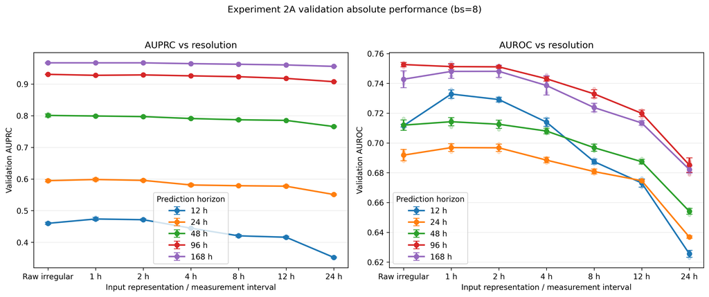

```
experiment2a_test_absolute_performance_ci95.png
===============================================
```

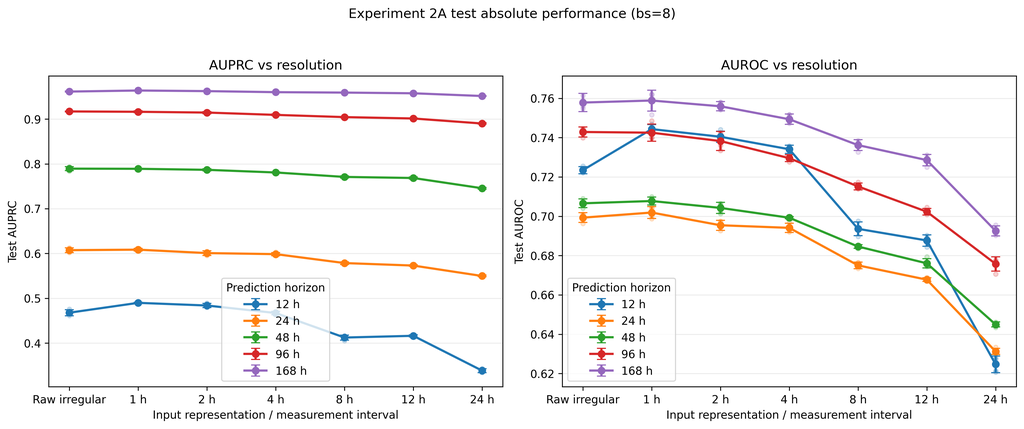

```python
for title, key in [
    ("Exp2A validation AUPRC", "exp2a_val_auprc_summary"),
    ("Exp2A validation AUROC", "exp2a_val_auroc_summary"),
    ("Exp2A test AUPRC", "exp2a_test_auprc_summary"),
    ("Exp2A test AUROC", "exp2a_test_auroc_summary"),
]:
    show_table(title_with_bs(title), add_status(DATA[key]), ["horizon", "timestep", "mean", "sd", "sem", "ci95_low", "ci95_high", "n", "status"])

show_source_plot_group(
    title_with_bs("Exp2A source figures: absolute performance"),
    "exp2a",
    FH_PLOTS,
    [
        "experiment2a_validation_absolute_performance_ci95.png",
        "experiment2a_test_absolute_performance_ci95.png",
    ],
)
```

**Degradation and bootstrap guide:** Degradation summaries show `1h - coarse` with Student-t CIs across seeds. The patient-bootstrap tables come from paired test predictions and include patient-level bootstrap CIs. Positive values mean the 1h/reference condition performed better; for Brier, positive means lower Brier for the reference.

```
Exp2A source figures: degradation (bs=8)
========================================

experiment2a_validation_degradation_ci95.png
============================================
```

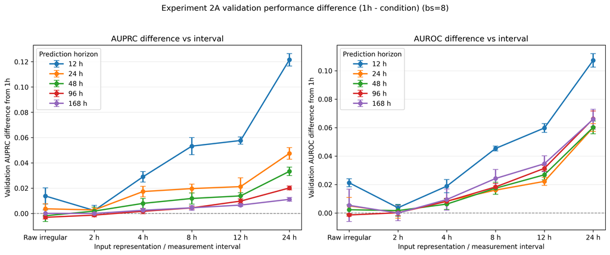

```
experiment2a_test_degradation_ci95.png
======================================
```

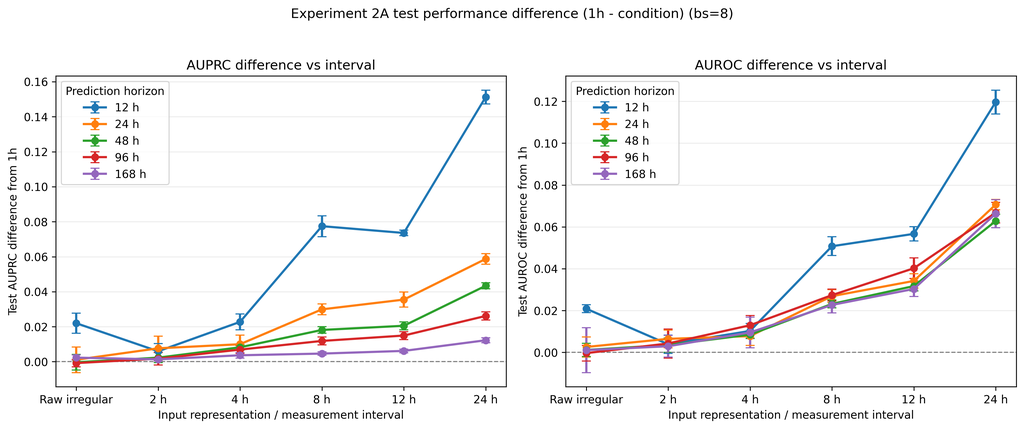

```python
for title, key in [
    ("Exp2A validation AUPRC degradation", "exp2a_val_auprc_drop_summary"),
    ("Exp2A validation AUROC degradation", "exp2a_val_auroc_drop_summary"),
    ("Exp2A test AUPRC degradation", "exp2a_test_auprc_drop_summary"),
    ("Exp2A test AUROC degradation", "exp2a_test_auroc_drop_summary"),
]:
    show_table(title_with_bs(title), add_status(DATA[key]), ["horizon", "timestep", "mean", "sd", "sem", "ci95_low", "ci95_high", "n", "status"])

show_source_plot_group(
    title_with_bs("Exp2A source figures: degradation"),
    "exp2a",
    FH_PLOTS,
    [
        "experiment2a_validation_degradation_ci95.png",
        "experiment2a_test_degradation_ci95.png",
    ],
)

exp2a_boot = add_status(DATA["exp2a_bootstrap_summary"], n_col="n_seeds")
show_table(title_with_bs("Exp2A across-seed paired patient-bootstrap summary"), exp2a_boot, ["horizon", "timestep", "metric", "mean_difference", "sd_difference", "seed_ci95_low", "seed_ci95_high", "patient_bootstrap_ci_low", "patient_bootstrap_ci_high", "n_seeds", "missing_seeds", "status"], max_rows=300)
```

## 3-4. Experiment 2B/C - Why Does Frequency Matter, And Does The Mechanism Depend On Severity?

### Scientific Question

Which parts of the frequency effect are associated with observation loss, temporal placement, and representation/grid changes? Does that mechanism change as thinning becomes more severe?

### Experimental Design

Model: LSTM. Task: fixed-horizon ICU outcome. Prediction time and horizons follow the source notebook. Conditions are preserved exactly from the source:

- A: native observations represented on the standard 1h grid.
- B: structured r-hour measurement selection/thinning; retained observations keep original timestamps and are represented on the downstream 1h grid.
- C: random matched-count thinning; for each patient-variable, retain the same effective number of observations as B but choose positions randomly from originally occupied 1h cells. Downstream representation remains 1h.
- D: standard r-hour discretization using the ordinary r-hour grid and therefore fewer recurrent steps.

| Condition | Observation selection | Observation count | Timing of retained observations | Representation grid | Recurrent sequence length | What changes relative to A |
| --- | --- | --- | --- | --- | --- | --- |
| **A: Dense / native** | No thinning | Full | Original timing | **1h** | Fixed by 1h grid | Reference |
| **B: Structured thinning** | Keep measurements according to an **r-hour structured schedule** | Reduced | Original timestamps of retained measurements | **1h** | Same grid length as A | Observation availability/frequency |
| **C: Random matched-count** | Randomly retain observations | Matched to B in both total observation count and per-variable observation count | Randomly selected occupied positions | **1h** | Same grid length as A/B | Temporal placement, while holding observation count approximately fixed |
| **D: Coarse grid** | No explicit thinning step | Measurements aggregated/represented on an **r-hour grid** | Coarsened to r-hour bins | **r-hour** | **Shorter than A/B/C** | Representation/granularity and sequence length |

Fixed across A–D: patient cohort, prediction task and horizon, input variables, model architecture/hyperparameters, and evaluation procedure. A–C all use the same 1h downstream grid, so B and C change which observations are available without changing recurrent sequence length. D changes the temporal representation itself by using an r-hour grid with fewer recurrent steps.

### Quantity Being Measured

Absolute performance compares the formal A/B/C/D condition metrics and, in the source figures, adds Raw irregular as a contextual reference when the exact Exp2A raw-LSTM predictions match the same horizon, model seeds, and test cohort. Raw irregular is not part of the formal Exp2B decomposition. Main displayed contrasts are A-vs-B, B-vs-C, B-vs-D, and A-vs-D. Positive contrast values mean the left condition is better; for Brier the source reverses sign so positive still means the left/reference condition has lower Brier.

| Contrast | Main question |
| --- | --- |
| **A − B** | What is lost when observations become systematically **less frequent**? |
| **B − C** | Does the **temporal pattern** of missing observations matter when observation count is matched? |
| **B − D** | Does changing the **representation/grid and recurrent sequence length** matter beyond sparse observation selection? |
| **A − D** | What is the total difference between the **native 1h benchmark representation** and ordinary **r-hour discretization**? |

### Why This Comparison Is Informative

A-vs-B isolates structured observation removal relative to native observations. B-vs-C asks whether temporal pattern matters after matching observation count. B-vs-D asks whether the coarse representation/grid changes performance beyond sparse observation selection. A-vs-D reports the total native-1h versus r-hour-grid difference.

### Expected Evidence

Increasing A-B with `r` suggests stronger information loss at lower observation frequency. Increasing B-C suggests temporal structure matters more with stronger thinning. Increasing B-D suggests representation/grid choice matters more. Flat curves suggest relative insensitivity to severity.

### Caveats

A/B/C/D are not an additive causal decomposition. B-vs-D is not a pure sequence-length contrast. Use only available `r` values; do not fabricate missing severities.

**Absolute condition guide:** The next table contains all exported A/B/C/D condition-level performance. Means and CIs are across model seeds. Brier raw values are lower-is-better here; only contrast tables use the positive-is-left-better sign convention. Completeness is based on available seed counts.

**Exp2B/C input-information characterization:** Structured thinning is introduced here at `r=4` only. Observed tokens are real `(timestamp, variable)` values in the first 24h window; occupied 1h bins and observed channels are also based on real observations, not imputed values. The post-discretization sequence length is shown only as a representation sanity check.

TODO: don't show A-D, be descriptive. contrasts are no good,

```python
exp2b_input_information_cols = [
    "condition", "n_stays",
    "mean_token_count", "median_token_count", "p25_token_count", "p75_token_count", "p95_token_count",
    "mean_token_retained_fraction", "median_token_retained_fraction",
    "mean_occupied_1h_bins", "median_occupied_1h_bins",
    "mean_channels_observed", "median_channels_observed",
    "post_discretization_sequence_length",
]
show_table(
    "Exp2B/C input-information characterization: dense vs structured r=4",
    DATA["exp2b_input_information_summary"],
    exp2b_input_information_cols,
    max_rows=20,
)
```

```
Exp2B/C source figures: condition-level performance with Raw irregular reference (bs=8)
=======================================================================================

experiment2b_r4_test_auroc_by_condition_ci95.png
================================================
```

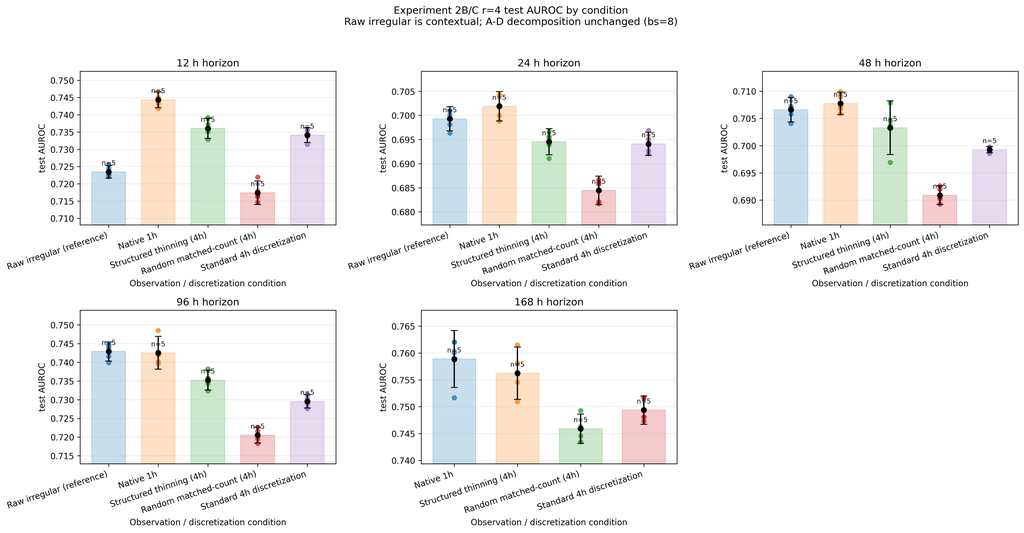

```
experiment2b_r4_test_auprc_by_condition_ci95.png
================================================
```

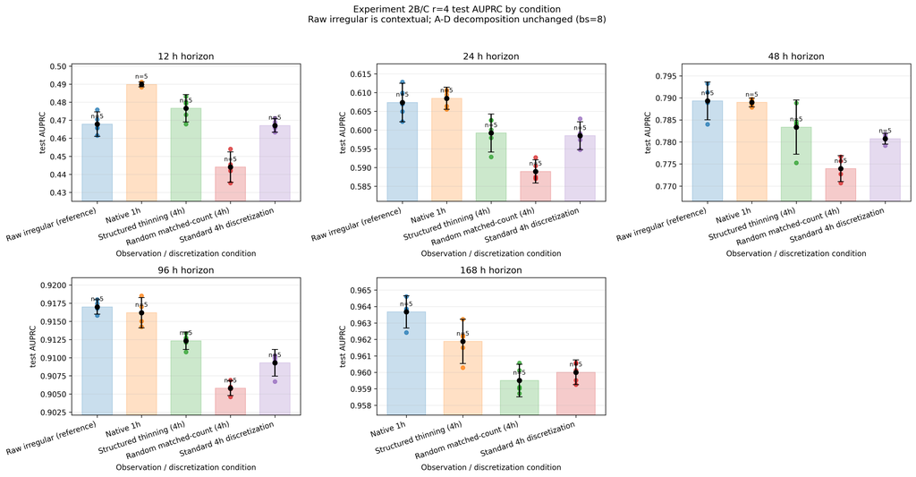

```
experiment2b_r4_test_brier_by_condition_ci95.png
================================================
```

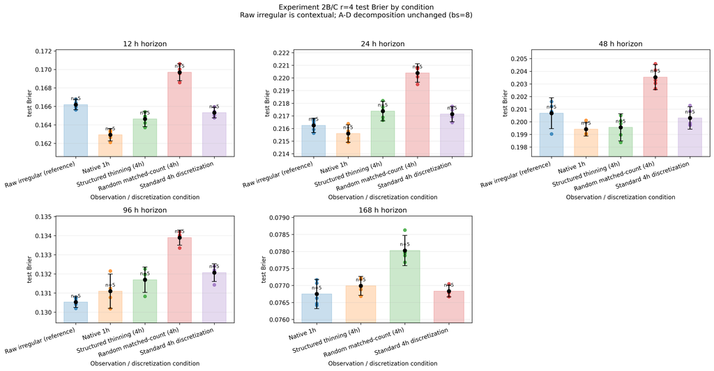

```python
CONDITION_ORDER = ["A", "B", "C", "D"]

exp2b_cond = add_status(DATA["exp2b_condition_summary"])

show_table(
    "Exp2B/C formal A-D condition-level summary",
    exp2b_cond,
    [
        "horizon", "r", "condition", "metric",
        "mean", "sd", "sem", "ci95_low", "ci95_high",
        "n", "status",
    ],
    max_rows=300,
)

show_source_plot_group(
    title_with_bs("Exp2B/C source figures: condition-level performance with Raw irregular reference"),
    "exp2bc",
    FH_PLOTS,
    exp2b_condition_plot_filenames(),
)
```

**Contrast guide:** The contrast tables show seed-level paired patient-bootstrap contrasts and across-seed summaries. Positive means the left condition is better; for Brier, positive means lower Brier for the left/reference condition. Patient-bootstrap CIs and Student-t seed CIs must be read separately.

```
Exp2B/C source figures: main mechanism contrasts (bs=8)
=======================================================

experiment2b_r4_auprc_primary_contrasts_bootstrap_ci95.png
==========================================================
```

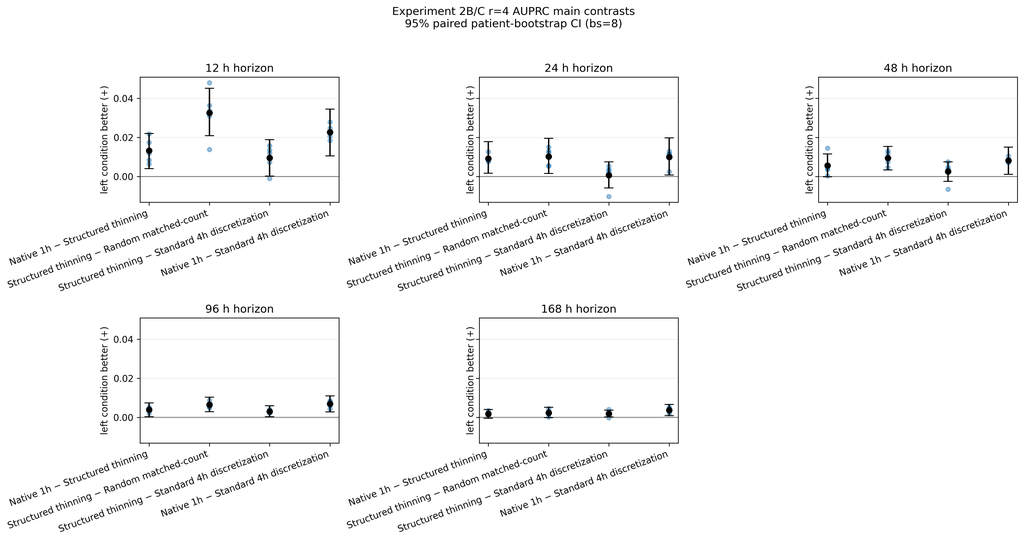

```
experiment2b_r4_auroc_primary_contrasts_bootstrap_ci95.png
==========================================================
```

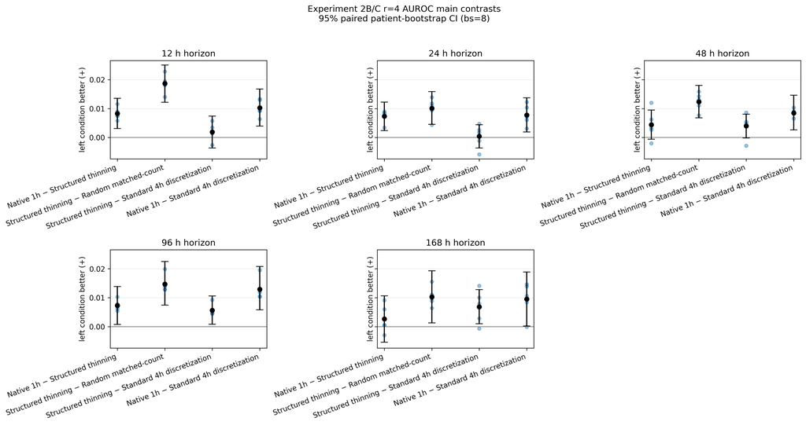

```
experiment2b_r4_brier_primary_contrasts_bootstrap_ci95.png
==========================================================
```

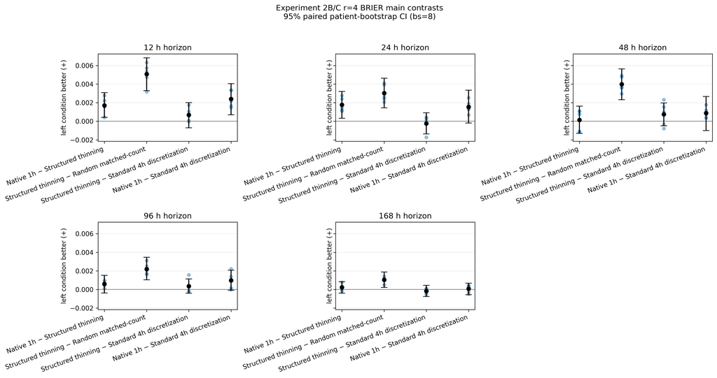

```python
exp2b_contrasts = add_status(DATA["exp2b_across_seed_summary"], n_col="n_seeds")
show_table(title_with_bs("Exp2B/C mechanism contrasts: seed Student-t CI and paired patient-bootstrap CI"), exp2b_contrasts, ["horizon", "r", "contrast", "contrast_display", "left_condition", "right_condition", "primary", "main_contrast", "metric", "mean_difference", "sd_difference", "sem_difference", "seed_ci95_low", "seed_ci95_high", "patient_bootstrap_ci_low", "patient_bootstrap_ci_high", "n_seeds", "missing_seeds", "status"], max_rows=300)

show_source_plot_group(
    title_with_bs("Exp2B/C source figures: main mechanism contrasts"),
    "exp2bc",
    FH_PLOTS,
    exp2b_primary_contrast_plot_filenames(),
)
```

**Exp2C thinning-severity table:** This is the same A/B/C/D mechanism evaluated across available thinning severities. Increasing effect size with `r` suggests stronger sensitivity as measurements become less frequent. Flat or non-monotonic results are also valid and should remain visible. Positive means the left condition is better, with Brier sign already oriented appropriately by the source analysis.

```python
exp2c_severity = exp2b_contrasts.copy()
if len(exp2c_severity):
    exp2c_severity = exp2c_severity.sort_values(["horizon", "r", "contrast", "metric"]).reset_index(drop=True)
show_table(title_with_bs("Exp2C thinning-severity mechanism table"), exp2c_severity, ["horizon", "r", "contrast", "left_condition", "right_condition", "metric", "mean_difference", "seed_ci95_low", "seed_ci95_high", "patient_bootstrap_ci_low", "patient_bootstrap_ci_high", "n_seeds", "missing_seeds", "status"], max_rows=300)

show_source_plot_group(
    title_with_bs("Exp2C source figures: mechanism severity across r"),
    "exp2bc",
    FH_PLOTS,
    exp2c_severity_plot_filenames(),
)
```

```
Exp2C source figures: mechanism severity across r (bs=8)
========================================================
NOT AVAILABLE
```

## 4. Experiment 3A-D - Regular-grid LSTM frequency-shift experiments

### Scientific Question

How much predictive performance is lost under train-test observation-frequency mismatch on the regular 1h grid, and how much is recovered by training on data with the same observation frequency as deployment? Is this effect robust to normalization, thinning mechanism, prediction horizon, and thinning severity?

### Experimental Design

Model: LSTM.

Task: fixed-horizon ICU outcome.

- Exp3A. Structured observation-frequency shift: h=12, r={4,8}. Compare (train on dense, test on sparse) vs (train on sparse, test on sparse). Dense = standard 1h discretization; sparse = structured thinning every (r) hours while keeping the 1h grid.
- Exp3B. Normalizer control: h=12, r=4. (sparse train + sparse test + sparse normalizer) vs (sparse train + sparse test + dense normalizer).
- Exp3C. Random-matched observation-frequency shift: h=12, r=4. Compare (train on dense, test on random-sparse) vs (train on random-sparse, test on random-sparse). Random-sparse randomly retains observations while matching the structured-r4 observation counts.
- Exp3D. Longer-horizon replication: h=96, r=4. Repeat Exp3A at a longer horizon.

### Quantity Being Measured

Absolute performance is condition-level AUPRC/AUROC/Brier by train regime, test regime, horizon, r, and normalizer regime. Main shift recovery for AUPRC/AUROC is `M(matched sparse -> sparse) - M(dense -> sparse)`. For Brier, the source uses `Brier(dense -> sparse) - Brier(matched sparse -> sparse)`, so positive consistently means improvement from matching the training observation regime.

### Why This Comparison Is Informative

It separates information loss at deployment from train/test observation-regime mismatch. The normalizer control asks whether normalization statistics explain the effect. Random matched thinning asks whether the mismatch persists without periodic structure. The h=96 replication links to Exp2A.

### Expected Evidence

Positive mismatch recovery suggests matched sparse training improves sparse deployment performance. Little normalizer-control difference suggests normalizer choice alone does not explain recovery. Structured-vs-random and r4-vs-r8 comparisons describe whether temporal pattern and severity matter.

### Caveats

A difference between regimes does not prove universal model robustness. LSTM Exp3 exports may be partial or unavailable if the source notebook run was interrupted. Do not call partial results final.

**Absolute performance guide:** These are raw condition-level test metrics summarized across seeds with Student-t CIs. Brier is lower-is-better in absolute tables. `status` flags partial seed availability. No patient-bootstrap interval is shown in this absolute table.

**Exp3A input-information characterization:** `r=8` first appears in Experiment 3A, so the dense/r4/r8 retained-information table is shown here. Sequence length remains a fixed 1h-grid sanity check, not an information-content metric.

TODO: 3E show 3 bars, and send reports of what is running, what combinations won't work

```python
exp3a_input_information_cols = [
    "condition", "r", "n_stays",
    "mean_token_count", "median_token_count", "p25_token_count", "p75_token_count", "p95_token_count",
    "mean_token_retained_fraction", "median_token_retained_fraction",
    "mean_occupied_1h_bins", "median_occupied_1h_bins",
    "mean_channels_observed", "median_channels_observed",
    "post_discretization_sequence_length",
]
show_table(
    "Exp3A input-information characterization: dense vs structured r=4/r=8",
    DATA["exp3a_input_information_summary"],
    exp3a_input_information_cols,
    max_rows=20,
)
```

```python
exp3_abs = add_status(DATA["exp3_lstm_absolute_summary"])
show_table(title_with_bs("Experiment 3 LSTM absolute performance"), exp3_abs, ["experiment", "horizon", "target_r", "condition", "normalizer_regime", "metric", "mean", "sd", "sem", "ci95_low", "ci95_high", "n", "status"], max_rows=300)
```

**Exp3A-D contrast guide:** The following tables come directly from the source LSTM summaries. Positive values mean the left/matched condition performs better. `seed_ci95_*` is a Student-t CI across model seeds. `patient_bootstrap_ci_*` is a paired patient-level bootstrap CI. Both are shown when exported.

```
Exp3 LSTM source figure: frequency-shift robustness (bs=8)
==========================================================
```

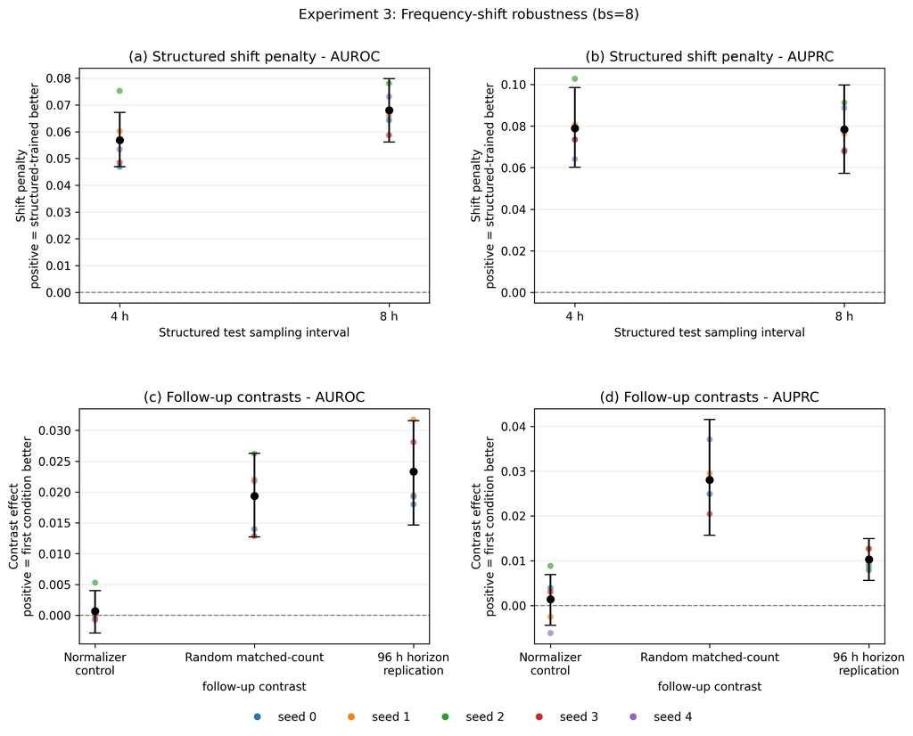

```python
for title, key in [
    ("Exp3A LSTM structured shift recovery", "exp3_lstm_structured_shift_summary"),
    ("Exp3B LSTM normalizer control", "exp3_lstm_normalizer_control_summary"),
    ("Exp3C LSTM random matched-count shift", "exp3_lstm_random_shift_summary"),
    ("Exp3D LSTM longer-horizon replication", "exp3_lstm_horizon_replication_summary"),
    ("Exp3 combined key-contrast summary", "exp3_lstm_combined_key_contrast_summary"),
    ("Exp3 final contrast coverage", "exp3_lstm_final_contrast_coverage"),
]:
    df = add_status(DATA[key], n_col="n_seeds")
    show_table(title_with_bs(title), df, ["experiment", "contrast", "horizon", "r", "metric", "left_condition", "right_condition", "mean_difference", "sd_difference", "seed_ci95_low", "seed_ci95_high", "patient_bootstrap_ci_low", "patient_bootstrap_ci_high", "n_seeds", "expected_seeds", "missing_seeds", "status", "present_in_final_summary", "final_reporting_ready"], max_rows=300)

show_source_plot(
    "exp3_lstm",
    FH_PLOTS,
    "experiment3_abcd_frequency_shift_bootstrap_ci95.png",
    title_with_bs("Exp3 LSTM source figure: frequency-shift robustness"),
)
```

## 5. Experiment 3E - Raw/irregular frequency-shift experiments

Exp3E tests whether observation-frequency mismatch persists when retained observations are represented as raw irregular sequences instead of only as a fixed 1h grid.

Raw LSTM removes the fixed 1h grid and preserves ordered retained observations, but it does not explicitly use irregular timestamps. Raw GRU-D removes the grid, uses retained irregular timestamps, preserves relative time gaps, and models variable-specific time since last observation.

**Exp3E raw/grid guide:** Raw mismatch recovery compares raw matched sparse training against raw dense-trained sparse deployment. Grid-vs-raw reports `Delta_grid - Delta_raw`; positive means the fixed-grid representation has a larger frequency-shift penalty than raw. The diagnostic compares grid matched-frequency against raw dense-trained as a descriptive robustness check, not an isolated causal contrast.

```python
for title, key in [
    ("Exp3E LSTM raw condition-level performance", "exp3e_lstm_raw_absolute_summary"),
    ("Exp3E LSTM raw mismatch recovery", "exp3e_lstm_raw_shift_summary"),
    ("Exp3E LSTM grid-vs-raw shift", "exp3_lstm_grid_vs_raw_shift_summary"),
    ("Exp3E LSTM grid-matched vs raw-dense diagnostic", "exp3e_lstm_grid_matched_vs_raw_dense_summary"),
]:
    df = add_status(DATA[key], n_col="n_seeds")
    show_table(title_with_bs(title), df, max_rows=300)

print("Exp3E LSTM comparison source figures are generated by visualize_exp3_grud_frequency_shift.ipynb.")
```

```
Exp3E LSTM comparison source figures are generated by visualize_exp3_grud_frequency_shift.ipynb.
```

**Raw representation characterization:** Raw inputs keep irregular timestamp rows rather than the fixed 1h grid. Token count is the number of retained observed variable values; timestamp-row count is the number of distinct retained raw timestamps needed to represent those values. The raw sequence-length sanity check is the retained raw row count after the 24h window filter and should not be interpreted as information content.

```python
exp3e_raw_characterization_cols = [
    "condition", "r", "n_stays",
    "mean_token_count", "median_token_count", "p25_token_count", "p75_token_count", "p95_token_count",
    "mean_token_retained_fraction", "median_token_retained_fraction",
    "mean_timestamp_rows", "median_timestamp_rows", "p25_timestamp_rows", "p75_timestamp_rows", "p95_timestamp_rows", "max_timestamp_rows",
    "mean_raw_sequence_length", "median_raw_sequence_length", "p25_raw_sequence_length", "p75_raw_sequence_length", "p95_raw_sequence_length", "max_raw_sequence_length",
]
show_table(
    "Exp3E raw representation token and timestamp-row characterization",
    DATA["exp3e_raw_representation_characterization_summary"],
    exp3e_raw_characterization_cols,
    max_rows=20,
)
```

### GRU-D frequency-shift results used by Exp3E

These are model-specific GRU-D summaries. They document the GRU-D provenance and frequency-shift results before the cross-model synthesis compares them with the LSTM outputs.

### Scientific Question

Does explicitly modeling observation masks and elapsed time with GRU-D change sensitivity to observation-frequency shift?

- (Recurrent Neural Networks for Multivariate Time Series with Missing Values, Scientific Reports 2018)

### Experimental Design

- Model: GRU-D.
- Task and Exp3A-D definitions follow the LSTM Exp3 notebook. Implemented analyses include structured shift at h=12 r=4/r=8, normalizer control at h=12 r=4, random matched-count h=12 r=4 sampling seed 100, and h=96 r=4 structured replication.

Exp3E adds the raw-representation question: raw GRU-D removes the fixed grid and explicitly uses retained irregular timestamps, relative time gaps, and variable-specific time since last observation.

### Quantity Being Measured

Absolute performance and mismatch/control contrasts use the same orientation as LSTM Exp3. For AUPRC/AUROC, positive recovery means matched sparse training performs better on sparse deployment. For Brier, positive means matched training has lower Brier because the source reports mismatched minus matched.

### Caveats

GRU-D runs may still be in progress. Partial result sets are valid exploratory outputs but not final evidence.

**GRU-D tables/plots guide:** Absolute tables use Student-t CIs across model seeds. Contrast summaries show both seed CIs and patient-bootstrap CIs when exported. Partial `n` is displayed instead of suppressing incomplete analyses.

```
GRU-D source figure: frequency-shift robustness (bs=8)
======================================================
```

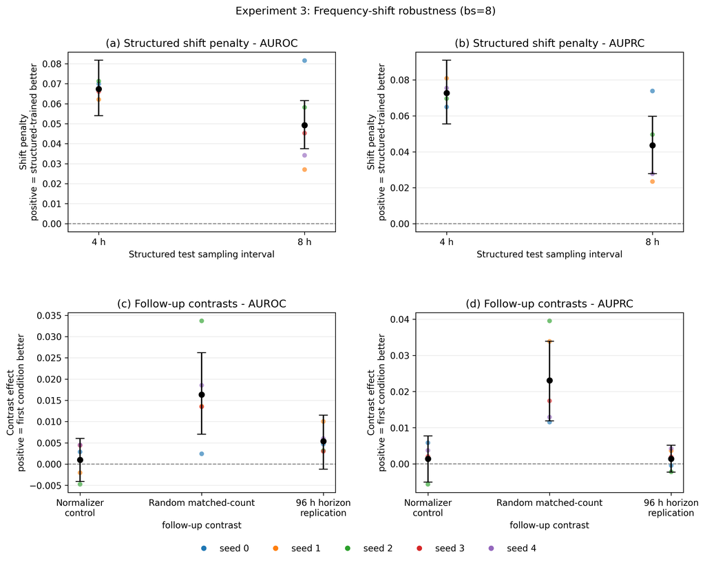

```python
for title, key in [
    ("GRU-D absolute condition performance", "exp3_grud_across_seed_summary"),
    ("GRU-D Exp3A structured shift", "exp3_grud_structured_shift_summary"),
    ("GRU-D Exp3B normalizer control", "exp3_grud_normalizer_control_summary"),
    ("GRU-D Exp3C random matched-count shift", "exp3_grud_random_shift_summary"),
    ("GRU-D Exp3D horizon replication", "exp3_grud_horizon_replication_summary"),
    ("GRU-D combined key-contrast summary", "exp3_grud_combined_key_contrast_summary"),
    ("GRU-D final status", "exp3_grud_final_status"),
    ("GRU-D final contrast coverage", "exp3_grud_final_contrast_coverage"),
]:
    df = add_status(DATA[key], n_col="n_seeds")
    show_table(title_with_bs(title), df, max_rows=300)

show_source_plot(
    "exp3_grud",
    FH_PLOTS,
    "experiment3_grud_abcd_frequency_shift_bootstrap_ci95.png",
    title_with_bs("GRU-D source figure: frequency-shift robustness"),
)
```

## 6. Does modeling irregular observations reduce sensitivity to frequency shift? (LSTM vs GRU-D)

These panels place corresponding LSTM and GRU-D source figures side by side to check whether the qualitative frequency-shift patterns differ by model architecture and temporal representation. They are visual juxtapositions of already-computed source-notebook results, not new statistical tests or architecture rankings.

The Exp3E grid-vs-raw shift-sensitivity panels lead this section because they now show matched target-frequency performance, grid-shift performance, and raw-shift performance side by side. That makes the model comparison easier to read as absolute performance rather than only as a penalty difference.

The r4-vs-r8 dense-trained information-loss analysis lives with Exp3A in `visualize_exp3_frequency_shift.ipynb`.

```
Exp3E raw mismatch penalty: LSTM vs GRU-D (bs=8)
================================================
```

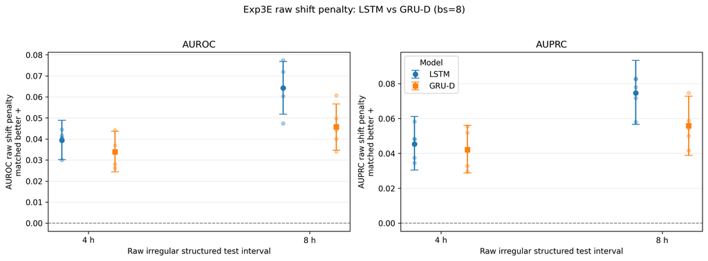

```
Exp3E grid-vs-raw shift sensitivity with matched baseline (AUPRC) (bs=8)
========================================================================
```

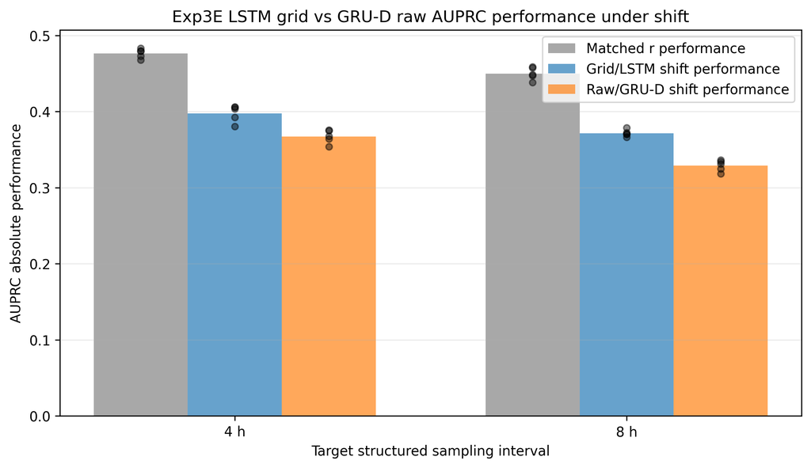

```
Exp3E grid-vs-raw shift sensitivity with matched baseline (AUROC) (bs=8)
========================================================================
```

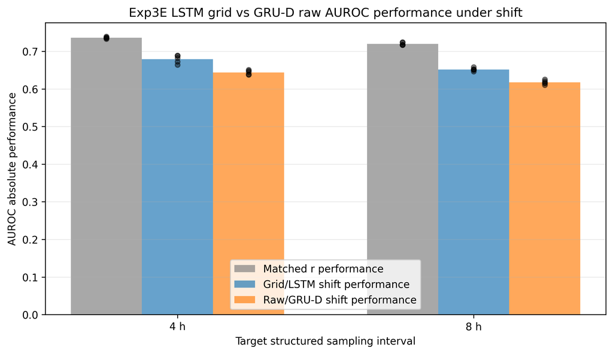

```python
for title, key in [
    ("Exp3E LSTM raw mismatch penalty", "exp3e_lstm_raw_shift_summary"),
    ("Exp3E GRU-D raw mismatch penalty", "exp3e_grud_raw_shift_summary"),
    ("Exp3E LSTM grid-vs-raw shift", "exp3_lstm_grid_vs_raw_shift_summary"),
    ("Exp3E GRU-D grid-vs-raw shift", "exp3_grud_grid_vs_raw_shift_summary"),
]:
    df = add_status(DATA[key], n_col="n_seeds")
    show_table(title_with_bs(title), df, max_rows=200)

show_source_plot(
    "exp3_grud",
    FH_PLOTS,
    "experiment3_grud_crossmodel_raw_shift_penalty_auroc_auprc_bootstrap_ci95.png",
    title_with_bs("Exp3E raw mismatch penalty: LSTM vs GRU-D"),
)

show_source_plot(
    "exp3_grud",
    FH_PLOTS,
    "experiment3_grud_grid_vs_raw_shift_auprc.png",
    title_with_bs("Exp3E grid-vs-raw shift sensitivity with matched baseline (AUPRC)"),
)

show_source_plot(
    "exp3_grud",
    FH_PLOTS,
    "experiment3_grud_grid_vs_raw_shift_auroc.png",
    title_with_bs("Exp3E grid-vs-raw shift sensitivity with matched baseline (AUROC)"),
)


def _exp3e_ci(row):
    for lo, hi, label in [
        ("patient_bootstrap_ci_low", "patient_bootstrap_ci_high", "patient bootstrap"),
        ("seed_ci95_low", "seed_ci95_high", "seed t"),
        ("student_t_ci95_low", "student_t_ci95_high", "seed t"),
        ("ci95_low", "ci95_high", "seed t"),
    ]:
        if lo in row and hi in row and pd.notna(row.get(lo)) and pd.notna(row.get(hi)):
            return row.get(lo), row.get(hi), label
    return np.nan, np.nan, None


def _exp3e_raw_shift_model_summary():
    rows = []
    for model, representation, key in [
        ("LSTM", "raw ordered sequence", "exp3e_lstm_raw_shift_summary"),
        ("GRU-D", "raw irregular timestamps", "exp3e_grud_raw_shift_summary"),
    ]:
        df = DATA[key]
        for _, row in df.iterrows() if len(df) else []:
            ci_low, ci_high, ci_type = _exp3e_ci(row)
            rows.append({
                "model": model,
                "representation": representation,
                "r": row.get("r"),
                "metric": row.get("metric"),
                "mismatch_penalty": row.get("mean_difference"),
                "ci_low": ci_low,
                "ci_high": ci_high,
                "ci_type": ci_type,
                "n_seeds": row.get("n_seeds"),
            })
    return pd.DataFrame(rows)


def _exp3e_grid_raw_model_summary():
    rows = []
    for model, key in [
        ("LSTM", "exp3_lstm_grid_vs_raw_shift_summary"),
        ("GRU-D", "exp3_grud_grid_vs_raw_shift_summary"),
    ]:
        df = DATA[key]
        for _, row in df.iterrows() if len(df) else []:
            ci_low, ci_high, ci_type = _exp3e_ci(row)
            rows.append({
                "model": model,
                "r": row.get("r"),
                "metric": row.get("metric"),
                "grid_shift": row.get("mean_grid_shift"),
                "raw_shift": row.get("mean_raw_shift"),
                "grid_minus_raw": row.get("mean_grid_minus_raw_shift"),
                "ci_low": ci_low,
                "ci_high": ci_high,
                "ci_type": ci_type,
                "n_seeds": row.get("n_seeds"),
            })
    return pd.DataFrame(rows)

show_table(
    "Exp3E raw mismatch penalty compact model summary",
    _exp3e_raw_shift_model_summary(),
    max_rows=200,
)
show_table(
    "Exp3E grid-vs-raw representation sensitivity compact model summary",
    _exp3e_grid_raw_model_summary(),
    max_rows=200,
)
```

```
13. Frequency-shift sensitivity: LSTM vs GRU-D (bs=8)
=====================================================
```

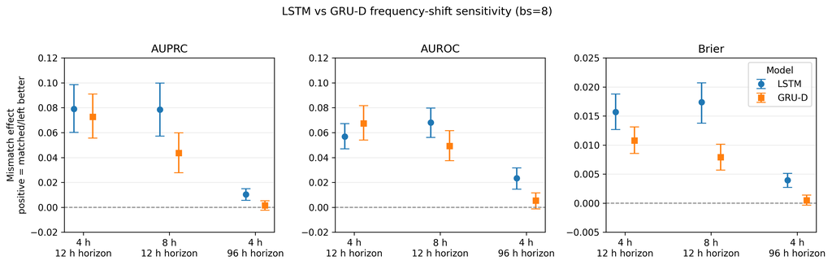

```
14. Structured vs random-matched thinning: LSTM vs GRU-D (bs=8)
===============================================================
```

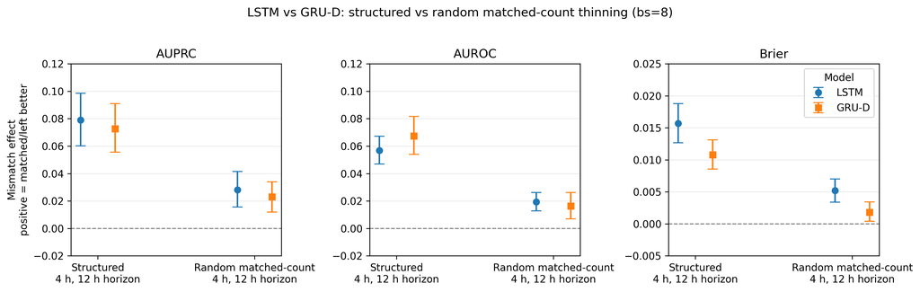

```
15. Mismatch recovery: r4 vs r8, LSTM vs GRU-D (bs=8)
=====================================================
```

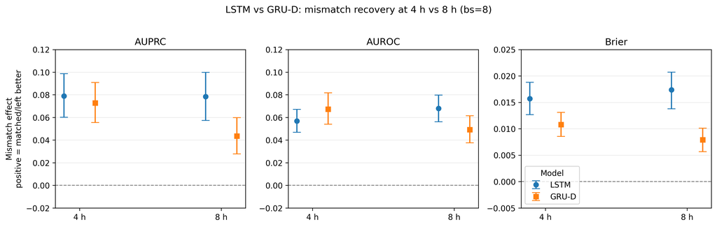

```
16. Short vs long horizon: LSTM vs GRU-D (bs=8)
===============================================
```

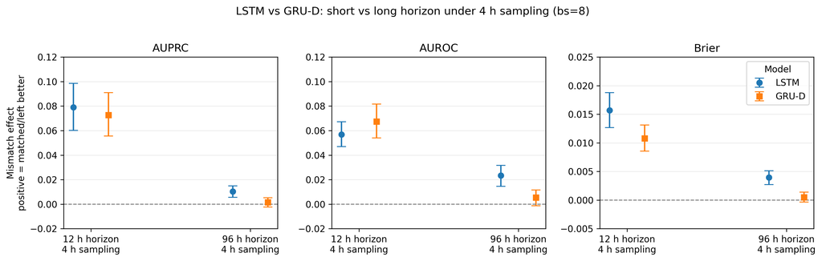

```python
show_source_plot(
    "exp3_grud",
    FH_PLOTS,
    "experiment3_grud_crossmodel_frequency_shift_sensitivity.png",
    title_with_bs("13. Frequency-shift sensitivity: LSTM vs GRU-D"),
)

show_source_plot(
    "exp3_grud",
    FH_PLOTS,
    "experiment3_grud_crossmodel_structured_vs_random_matched.png",
    title_with_bs("14. Structured vs random-matched thinning: LSTM vs GRU-D"),
)

show_source_plot(
    "exp3_grud",
    FH_PLOTS,
    "experiment3_grud_crossmodel_r4_vs_r8_mismatch_recovery.png",
    title_with_bs("15. Mismatch recovery: r4 vs r8, LSTM vs GRU-D"),
)

show_source_plot(
    "exp3_grud",
    FH_PLOTS,
    "experiment3_grud_crossmodel_short_vs_long_horizon.png",
    title_with_bs("16. Short vs long horizon: LSTM vs GRU-D"),
)
```

## 7. Overall synthesis / diagnostics / conclusions

This overview separates observed information from representation structure. Observed tokens, retained fraction, occupied 1h bins, and observed channels describe real measurements retained after sampling. Raw timestamp rows and post-discretization sequence length describe how the retained measurements are represented for the model. Rows are assembled only from saved characterization CSVs produced by the experiment notebooks.

TODO: narrow down scope, what are the sensitive things TODO: are there better ways than inserting the time gap to rnn

### Column Definitions

**Representation and information summary**

- `representation`: Representation/regime summarized in the row. `dense`, `structured-r4`, and `structured-r8` are fixed-grid representations; `dense/raw`, `structured-r4/raw`, and `structured-r8/raw` are raw event-sequence representations with the same retained observation regime.
- `introduced_in`: Experiment section where this representation/regime is first introduced or used as the relevant comparison.
- `mean_observed_tokens`: Mean post-transform observed mask cells per stay in the 24h input window. Fixed-grid rows sum 1h `Discretizer` `mask->*` columns; raw rows sum `RawSequenceEncoder` `mask->*` columns.
- `median_observed_tokens`: Median post-transform observed mask cells per stay, using the same representation-specific mask source as `mean_observed_tokens`.
- `mean_raw_observed_tokens`: Mean dense raw-event mask cells per stay, used as the denominator for retained-token fractions.
- `mean_token_retained_fraction`: Mean, over stays, of retained post-transform mask cells divided by dense raw-event mask cells for the same stay. Thus fixed-grid dense can be below 1.0, while dense/raw is 1.0.
- `mean_occupied_1h_bins`: Mean number of 1h discretizer rows containing at least one real retained observation. Applies only to fixed-grid representations; raw rows are not 1h-discretized.
- `mean_channels_observed`: Mean number of variables/channels with at least one post-transform observed mask cell per stay.
- `mean_raw_timestamp_rows`: Mean number of distinct retained raw timestamps per stay. Applies only to raw representations.
- `median_raw_timestamp_rows`: Median number of distinct retained raw timestamps per stay. Applies only to raw representations.
- `post_discretization_sequence_length`: Fixed recurrent sequence length after 1h discretization. Applies only to fixed-grid representations.
- `mean_raw_sequence_length`: Mean raw event-sequence length per stay. Applies only to raw representations.
- `median_raw_sequence_length`: Median raw event-sequence length per stay. Applies only to raw representations.

**Representation per-variable `mean_token_retained_fraction`**

- `representation`: Representation/regime for the per-variable row.
- `introduced_in`: Experiment section where this representation/regime is first introduced or used as the relevant comparison.
- `variable`: Input variable/channel name, sorted alphabetically within each representation.
- `mean_raw_token_count`: Mean dense raw-event mask-cell count per stay for this variable; denominator for the retained fraction.
- `mean_token_count`: Mean retained post-transform observed mask-cell count per stay for this variable under the row representation/regime.
- `mean_token_retained_fraction`: Per-variable retained-token ratio, computed in the source characterization export as `mean_token_count / mean_raw_token_count`. It is `NaN` when `mean_raw_token_count` is 0 because the ratio is undefined.

Representation and information summary

|  | representation | introduced_in | mean_observed_tokens | median_observed_tokens | mean_raw_observed_tokens | mean_token_retained_fraction | mean_occupied_1h_bins | mean_channels_observed | mean_raw_timestamp_rows | median_raw_timestamp_rows | post_discretization_sequence_length | mean_raw_sequence_length | median_raw_sequence_length |
| --- | --- | --- | --- | --- | --- | --- | --- | --- | --- | --- | --- | --- | --- |
| 0 | dense | baseline | 58.712742 | 9.0 | 70.706527 | 0.930696 | 10.381086 | 5.211188 | NaN | NaN | 24.0 | NaN | NaN |
| 1 | structured-r4 | Exp2B/C | 22.729022 | 7.0 | 70.706527 | 0.684687 | 6.838686 | 5.211188 | NaN | NaN | 24.0 | NaN | NaN |
| 2 | structured-r8 | Exp3A | 13.128607 | 5.0 | 70.706527 | 0.566834 | 4.833062 | 5.211188 | NaN | NaN | 24.0 | NaN | NaN |
| 3 | dense/raw | Exp3E | 70.706527 | 9.0 | 70.706527 | 1.000000 | NaN | 5.211188 | 18.847565 | 7.0 | NaN | 18.851709 | 7.0 |
| 4 | structured-r4/raw | Exp3E | 22.729022 | 7.0 | 70.706527 | 0.684687 | NaN | 5.211188 | 9.028119 | 5.0 | NaN | 9.028119 | 5.0 |
| 5 | structured-r8/raw | Exp3E | 13.128607 | 5.0 | 70.706527 | 0.566834 | NaN | 5.211188 | 5.983869 | 4.0 | NaN | 5.983869 | 4.0 |

```
Raw measurement density sample
==============================
sampled patients/stays: 100
random seed: 12345
total raw observations represented: 6634
observation window: 0-24 hours after ICU admission
```

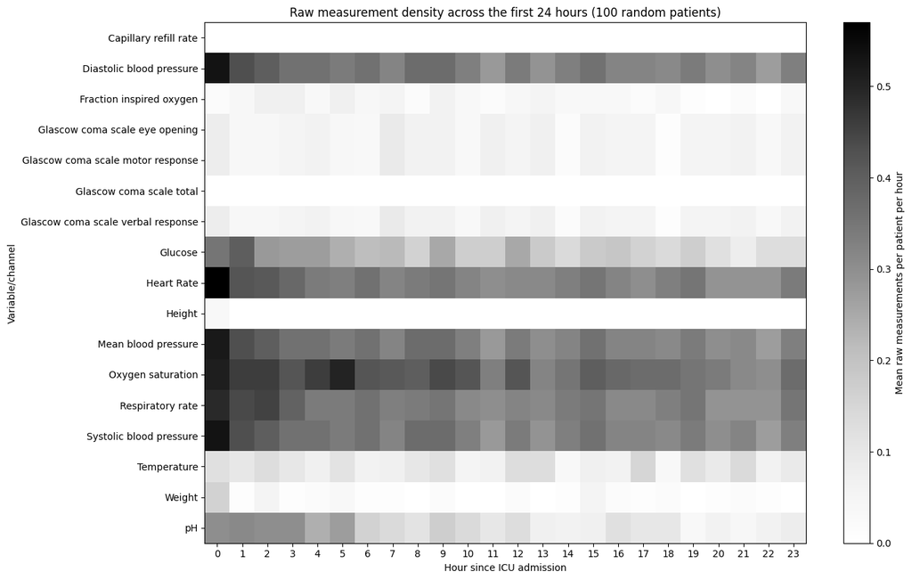

```python
def _summary_row(df, condition):
    if df is None or len(df) == 0:
        raise RuntimeError("Missing characterization table while building representation summary")
    sub = df[df["condition"].astype(str) == condition]
    if len(sub) != 1:
        raise RuntimeError("Expected one characterization row for {}; got {}".format(condition, len(sub)))
    return sub.iloc[0]


def _grid_representation_row(source, condition, representation, introduced_in):
    row = _summary_row(source, condition)
    return {
        "representation": representation,
        "introduced_in": introduced_in,
        "mean_observed_tokens": row.get("mean_token_count", np.nan),
        "median_observed_tokens": row.get("median_token_count", np.nan),
        "mean_raw_observed_tokens": row.get("mean_raw_token_count", np.nan),
        "mean_token_retained_fraction": row.get("mean_token_retained_fraction", np.nan),
        "mean_occupied_1h_bins": row.get("mean_occupied_1h_bins", np.nan),
        "mean_channels_observed": row.get("mean_channels_observed", np.nan),
        "mean_raw_timestamp_rows": np.nan,
        "median_raw_timestamp_rows": np.nan,
        "post_discretization_sequence_length": row.get("post_discretization_sequence_length", np.nan),
        "mean_raw_sequence_length": np.nan,
        "median_raw_sequence_length": np.nan,
    }


def _raw_representation_row(raw_source, grid_source, raw_condition, grid_condition, representation, introduced_in):
    raw = _summary_row(raw_source, raw_condition)
    return {
        "representation": representation,
        "introduced_in": introduced_in,
        "mean_observed_tokens": raw.get("mean_token_count", np.nan),
        "median_observed_tokens": raw.get("median_token_count", np.nan),
        "mean_raw_observed_tokens": raw.get("mean_raw_token_count", np.nan),
        "mean_token_retained_fraction": raw.get("mean_token_retained_fraction", np.nan),
        "mean_occupied_1h_bins": np.nan,
        "mean_channels_observed": raw.get("mean_channels_observed", np.nan),
        "mean_raw_timestamp_rows": raw.get("mean_timestamp_rows", np.nan),
        "median_raw_timestamp_rows": raw.get("median_timestamp_rows", np.nan),
        "post_discretization_sequence_length": np.nan,
        "mean_raw_sequence_length": raw.get("mean_raw_sequence_length", np.nan),
        "median_raw_sequence_length": raw.get("median_raw_sequence_length", np.nan),
    }


representation_information_summary = pd.DataFrame([
    _grid_representation_row(DATA["exp2b_input_information_summary"], "dense", "dense", "baseline"),
    _grid_representation_row(DATA["exp2b_input_information_summary"], "structured-r4", "structured-r4", "Exp2B/C"),
    _grid_representation_row(DATA["exp3a_input_information_summary"], "structured-r8", "structured-r8", "Exp3A"),
    _raw_representation_row(DATA["exp3e_raw_representation_characterization_summary"], DATA["exp3a_input_information_summary"], "dense/raw", "dense", "dense/raw", "Exp3E"),
    _raw_representation_row(DATA["exp3e_raw_representation_characterization_summary"], DATA["exp3a_input_information_summary"], "structured-r4/raw", "structured-r4", "structured-r4/raw", "Exp3E"),
    _raw_representation_row(DATA["exp3e_raw_representation_characterization_summary"], DATA["exp3a_input_information_summary"], "structured-r8/raw", "structured-r8", "structured-r8/raw", "Exp3E"),
])

representation_information_cols = [
    "representation", "introduced_in",
    "mean_observed_tokens", "median_observed_tokens", "mean_raw_observed_tokens",
    "mean_token_retained_fraction",
    "mean_occupied_1h_bins", "mean_channels_observed",
    "mean_raw_timestamp_rows", "median_raw_timestamp_rows",
    "post_discretization_sequence_length",
    "mean_raw_sequence_length", "median_raw_sequence_length",
]
representation_information_summary = representation_information_summary[representation_information_cols]
show_table("Representation and information summary", representation_information_summary, max_rows=20, always_show=True)



def _source_variable_retention(key, conditions, introduced_in_by_condition):
    df = DATA.get(key)
    if df is None or len(df) == 0:
        return pd.DataFrame()
    required = [
        "condition", "r", "channel",
        "mean_raw_token_count", "mean_token_count",
        "mean_token_retained_fraction",
    ]
    missing = [col for col in required if col not in df.columns]
    if missing:
        raise RuntimeError("{} is missing source per-variable columns: {}".format(key, missing))
    out = df[df["condition"].astype(str).isin(conditions)].copy()
    out["representation"] = out["condition"].astype(str)
    out["introduced_in"] = out["representation"].map(introduced_in_by_condition)
    out = out.rename(columns={"channel": "variable"})
    return out[[
        "representation", "introduced_in", "variable",
        "mean_raw_token_count", "mean_token_count",
        "mean_token_retained_fraction",
    ]]


representation_variable_retention = pd.concat([
    _source_variable_retention(
        "exp2b_input_information_channel_retention",
        ["dense", "structured-r4"],
        {"dense": "baseline", "structured-r4": "Exp2B/C"},
    ),
    _source_variable_retention(
        "exp3a_input_information_channel_retention",
        ["structured-r8"],
        {"structured-r8": "Exp3A"},
    ),
    _source_variable_retention(
        "exp3e_raw_representation_channel_retention",
        ["dense/raw", "structured-r4/raw", "structured-r8/raw"],
        {
            "dense/raw": "Exp3E",
            "structured-r4/raw": "Exp3E",
            "structured-r8/raw": "Exp3E",
        },
    ),
], ignore_index=True)
representation_variable_order = {
    representation: order
    for order, representation in enumerate(representation_information_summary["representation"].tolist())
}
representation_variable_retention["representation_order"] = (
    representation_variable_retention["representation"].map(representation_variable_order)
)
representation_variable_retention = representation_variable_retention.sort_values(
    ["representation_order", "variable"]
).drop(["representation_order"], axis=1).reset_index(drop=True)
show_table(
    "Representation per-variable mean_token_retained_fraction",
    representation_variable_retention,
    [
        "representation", "introduced_in", "variable",
        "mean_raw_token_count", "mean_token_count",
        "mean_token_retained_fraction",
    ],
    max_rows=200,
)


# Raw measurement density heatmap for the same 24h fixed-horizon test population.
RAW_DENSITY_SAMPLE_SIZE = 100
RAW_DENSITY_SAMPLE_SEED = 12345
RAW_DENSITY_WINDOW_HOURS = 24
RAW_DENSITY_HORIZON = 12


def _section17_fixed_horizon_reader(horizon=RAW_DENSITY_HORIZON):
    import sys as _sys
    if str(REPO_DIR) not in _sys.path:
        _sys.path.insert(0, str(REPO_DIR))
    from mimic4benchmark.readers import FixedHorizonIcuExitReader

    data_dir = PROJECT_DATA_ROOT / "data/length-of-stay"
    return FixedHorizonIcuExitReader(
        dataset_dir=str(data_dir / "test"),
        listfile=str(data_dir / "test_listfile.csv"),
        horizon=int(horizon),
    )


def _raw_measurement_counts_by_hour(example, channel_order, window_hours=RAW_DENSITY_WINDOW_HOURS):
    header = list(example["header"])
    if not header or header[0] != "Hours":
        raise RuntimeError("Expected raw reader header to start with Hours")
    source_channels = header[1:]
    missing = [channel for channel in channel_order if channel not in source_channels]
    if missing:
        raise RuntimeError("Raw reader is missing channels: {}".format(missing))

    X = example["X"]
    hours = np.asarray(X[:, 0], dtype=float)
    in_window = (hours >= -1e-7) & (hours <= float(window_hours) + 1e-7)
    hours = hours[in_window]
    values = X[in_window, 1:]
    # ponytail: exact 24.0 is inside the source 24h window, so put it in 23-24h.
    hour_ids = np.floor(np.clip(hours, 0.0, float(window_hours) - 1e-7)).astype(int)

    counts_by_source_channel = np.zeros((len(source_channels), int(window_hours)), dtype=float)
    observed = values != ""
    for hour in range(int(window_hours)):
        rows = hour_ids == hour
        if np.any(rows):
            counts_by_source_channel[:, hour] = np.sum(observed[rows, :], axis=0)
    source_channel_ids = [source_channels.index(channel) for channel in channel_order]
    return counts_by_source_channel[source_channel_ids, :]


def _self_check_raw_measurement_counts_by_hour():
    fake = {
        "header": ["Hours", "A", "B"],
        "X": np.asarray([
            ["0.0", "1", ""],
            ["0.999", "", "2"],
            ["1.0", "3", "4"],
            ["24.0", "5", ""],
        ], dtype=object),
    }
    counts = _raw_measurement_counts_by_hour(fake, ["A", "B"], window_hours=24)
    assert counts.shape == (2, 24)
    assert counts[0, 0] == 1 and counts[1, 0] == 1
    assert counts[0, 1] == 1 and counts[1, 1] == 1
    assert counts[0, 23] == 1 and counts[1, 23] == 0


_self_check_raw_measurement_counts_by_hour()

raw_density_reader = _section17_fixed_horizon_reader()
raw_density_n_available = raw_density_reader.get_number_of_examples()
if raw_density_n_available < RAW_DENSITY_SAMPLE_SIZE:
    raise RuntimeError(
        "Need at least {} stays for raw density sample; found {}".format(
            RAW_DENSITY_SAMPLE_SIZE, raw_density_n_available
        )
    )

raw_density_first_example = raw_density_reader.read_example(0)
raw_density_variable_order = representation_variable_retention[
    representation_variable_retention["representation"].astype(str).eq("dense/raw")
]["variable"].tolist()
if not raw_density_variable_order:
    raw_density_variable_order = list(raw_density_first_example["header"])[1:]

raw_density_rng = np.random.RandomState(RAW_DENSITY_SAMPLE_SEED)
raw_density_indices = raw_density_rng.choice(
    raw_density_n_available, size=RAW_DENSITY_SAMPLE_SIZE, replace=False
)
raw_density_counts = np.zeros(
    (len(raw_density_variable_order), RAW_DENSITY_WINDOW_HOURS), dtype=float
)
for raw_density_index in raw_density_indices:
    raw_density_counts += _raw_measurement_counts_by_hour(
        raw_density_reader.read_example(int(raw_density_index)),
        raw_density_variable_order,
        window_hours=RAW_DENSITY_WINDOW_HOURS,
    )

raw_density_total_observations = int(raw_density_counts.sum())
raw_density_mean_counts = raw_density_counts / float(RAW_DENSITY_SAMPLE_SIZE)

print("Raw measurement density sample")
print("==============================")
print("sampled patients/stays: {}".format(RAW_DENSITY_SAMPLE_SIZE))
print("random seed: {}".format(RAW_DENSITY_SAMPLE_SEED))
print("total raw observations represented: {}".format(raw_density_total_observations))
print("observation window: 0-{} hours after ICU admission".format(RAW_DENSITY_WINDOW_HOURS))

import matplotlib.pyplot as plt

fig_height = max(8.0, 0.38 * len(raw_density_variable_order) + 2.0)
fig, ax = plt.subplots(figsize=(14, fig_height))
im = ax.imshow(raw_density_mean_counts, aspect="auto", interpolation="nearest", cmap="Greys")
ax.set_title("Raw measurement density across the first 24 hours (100 random patients)")
ax.set_xlabel("Hour since ICU admission")
ax.set_ylabel("Variable/channel")
ax.set_xticks(np.arange(RAW_DENSITY_WINDOW_HOURS))
ax.set_xticklabels(np.arange(RAW_DENSITY_WINDOW_HOURS))
ax.set_yticks(np.arange(len(raw_density_variable_order)))
ax.set_yticklabels(raw_density_variable_order)
colorbar = fig.colorbar(im, ax=ax)
colorbar.set_label("Mean raw measurements per patient per hour")
fig.tight_layout()
```

```python
master_rows = []


def add_master(row):
    base = {
        "experiment": None, "subexperiment": None, "task": None, "model": None,
        "representation": None, "prediction_time": None, "horizon": None, "resolution_or_r": None,
        "train_regime": None, "test_regime": None, "normalizer_regime": None,
        "comparison": None, "metric": None, "effect": np.nan,
        "effect_orientation": None,
        "seed_ci_low": np.nan, "seed_ci_high": np.nan,
        "patient_ci_low": np.nan, "patient_ci_high": np.nan,
        "n_seeds": np.nan, "expected_n_seeds": 5, "missing_seeds": None,
        "batch_size": None, "status": "NOT AVAILABLE", "source_notebook": None,
    }
    base.update(row)
    if base.get("batch_size") is None:
        base["batch_size"] = batch_size_for_task(base.get("task"))
    if pd.notna(base.get("n_seeds", np.nan)):
        base["status"] = status_from_n(base["n_seeds"], base.get("expected_n_seeds", 5))
    master_rows.append(base)


for prefix, fallback_task, source in [
    ("exp1", "in-hospital mortality", "visualize_exp1_frequency.ipynb"),
    ("exp1_decomp", "decompensation", "visualize_exp1_frequency.ipynb"),
]:
    for metric, df in [
        ("auprc", DATA["{}_auprc_drop_summary".format(prefix)]),
        ("auroc", DATA["{}_auroc_drop_summary".format(prefix)]),
    ]:
        for _, r in df.iterrows() if len(df) else []:
            add_master({"experiment": "Exp1", "subexperiment": "degradation from 1h", "task": r.get("task", fallback_task), "model": "LSTM", "representation": r.get("condition"), "resolution_or_r": r.get("timestep"), "comparison": "1h - condition", "metric": metric, "effect": r.get("mean"), "effect_orientation": "positive = degradation under lower-frequency or raw condition", "seed_ci_low": r.get("ci95_low"), "seed_ci_high": r.get("ci95_high"), "n_seeds": r.get("n"), "source_notebook": source})


def exp2a_key(horizon, resolution, metric):
    return (int(horizon), float(resolution), str(metric))


exp2a_rows = {}
exp2a_master_inconsistencies = []
for metric, df in [("auprc", DATA["exp2a_test_auprc_drop_summary"]), ("auroc", DATA["exp2a_test_auroc_drop_summary"])]:
    for _, r in df.iterrows() if len(df) else []:
        key = exp2a_key(r.get("horizon"), r.get("timestep"), metric)
        exp2a_rows[key] = {
            "experiment": "Exp2A",
            "subexperiment": "test degradation from 1h + paired patient bootstrap",
            "task": "fixed-horizon ICU outcome",
            "model": "LSTM",
            "prediction_time": "24h after ICU admission",
            "horizon": r.get("horizon"),
            "resolution_or_r": r.get("timestep"),
            "comparison": "1h - coarse",
            "metric": metric,
            "effect": r.get("mean"),
            "effect_orientation": "positive = degradation under coarser resolution; Brier reversed where available",
            "seed_ci_low": r.get("ci95_low"),
            "seed_ci_high": r.get("ci95_high"),
            "n_seeds": r.get("n"),
            "source_notebook": "visualize_exp2a_horizon.ipynb",
        }

for _, r in DATA["exp2a_bootstrap_summary"].iterrows() if len(DATA["exp2a_bootstrap_summary"]) else []:
    key = exp2a_key(r.get("horizon"), r.get("timestep"), r.get("metric"))
    if key in exp2a_rows:
        base = exp2a_rows[key]
        source_effect = base.get("effect")
        boot_effect = r.get("mean_difference")
        if pd.notna(source_effect) and pd.notna(boot_effect) and abs(float(source_effect) - float(boot_effect)) > 1e-6:
            exp2a_master_inconsistencies.append({
                "horizon": r.get("horizon"),
                "resolution": r.get("timestep"),
                "metric": r.get("metric"),
                "degradation_effect": source_effect,
                "bootstrap_effect": boot_effect,
                "absolute_difference": abs(float(source_effect) - float(boot_effect)),
            })
        base.update({
            "patient_ci_low": r.get("patient_bootstrap_ci_low"),
            "patient_ci_high": r.get("patient_bootstrap_ci_high"),
            "missing_seeds": r.get("missing_seeds"),
        })
        if pd.isna(base.get("n_seeds", np.nan)):
            base["n_seeds"] = r.get("n_seeds")
        if pd.isna(base.get("seed_ci_low", np.nan)):
            base["seed_ci_low"] = r.get("seed_ci95_low")
        if pd.isna(base.get("seed_ci_high", np.nan)):
            base["seed_ci_high"] = r.get("seed_ci95_high")
    else:
        exp2a_rows[key] = {
            "experiment": "Exp2A",
            "subexperiment": "paired patient bootstrap",
            "task": "fixed-horizon ICU outcome",
            "model": "LSTM",
            "prediction_time": "24h after ICU admission",
            "horizon": r.get("horizon"),
            "resolution_or_r": r.get("timestep"),
            "comparison": "1h - coarse",
            "metric": r.get("metric"),
            "effect": r.get("mean_difference"),
            "effect_orientation": "positive = 1h/reference better; Brier reversed",
            "seed_ci_low": r.get("seed_ci95_low"),
            "seed_ci_high": r.get("seed_ci95_high"),
            "patient_ci_low": r.get("patient_bootstrap_ci_low"),
            "patient_ci_high": r.get("patient_bootstrap_ci_high"),
            "n_seeds": r.get("n_seeds"),
            "missing_seeds": r.get("missing_seeds"),
            "source_notebook": "visualize_exp2a_horizon.ipynb",
        }

for key in sorted(exp2a_rows):
    add_master(exp2a_rows[key])

if exp2a_master_inconsistencies:
    show_table(title_with_bs("Exp2A degradation/bootstrap point-estimate inconsistencies"), pd.DataFrame(exp2a_master_inconsistencies), max_rows=100)

for _, r in DATA["exp2b_across_seed_summary"].iterrows() if len(DATA["exp2b_across_seed_summary"]) else []:
    add_master({"experiment": "Exp2B/C", "subexperiment": "A/B/C/D mechanism", "task": "fixed-horizon ICU outcome", "model": "LSTM", "horizon": r.get("horizon"), "resolution_or_r": r.get("r"), "train_regime": r.get("left_condition"), "test_regime": r.get("right_condition"), "comparison": r.get("contrast"), "metric": r.get("metric"), "effect": r.get("mean_difference"), "effect_orientation": "positive = left condition better; Brier reversed", "seed_ci_low": r.get("seed_ci95_low"), "seed_ci_high": r.get("seed_ci95_high"), "patient_ci_low": r.get("patient_bootstrap_ci_low"), "patient_ci_high": r.get("patient_bootstrap_ci_high"), "n_seeds": r.get("n_seeds"), "missing_seeds": r.get("missing_seeds"), "source_notebook": "visualize_exp2b_matched_count.ipynb"})

for key, model, representation, source in [
    ("exp3_lstm_combined_key_contrast_summary", "LSTM", "fixed 1h grid", "visualize_exp3_frequency_shift.ipynb"),
    ("exp3_grud_combined_key_contrast_summary", "GRU-D", "fixed 1h grid", "visualize_exp3_grud_frequency_shift.ipynb"),
]:
    df = DATA[key]
    for _, r in df.iterrows() if len(df) else []:
        if str(r.get("experiment", "")).startswith("Exp3E"):
            continue
        add_master({"experiment": "Exp3", "subexperiment": r.get("experiment"), "task": "fixed-horizon ICU outcome", "model": model, "representation": representation, "horizon": r.get("horizon"), "resolution_or_r": r.get("r"), "train_regime": r.get("left_condition"), "test_regime": r.get("right_condition"), "normalizer_regime": "{} vs {}".format(r.get("left_normalizer_regime"), r.get("right_normalizer_regime")), "comparison": r.get("contrast"), "metric": r.get("metric"), "effect": r.get("mean_difference"), "effect_orientation": "positive = left/matched condition better; Brier reversed", "seed_ci_low": r.get("seed_ci95_low", r.get("student_t_ci95_low")), "seed_ci_high": r.get("seed_ci95_high", r.get("student_t_ci95_high")), "patient_ci_low": r.get("patient_bootstrap_ci_low"), "patient_ci_high": r.get("patient_bootstrap_ci_high"), "n_seeds": r.get("n_seeds"), "missing_seeds": r.get("missing_seeds"), "source_notebook": source})

for key, model, representation, source in [
    ("exp3e_lstm_raw_shift_summary", "LSTM", "raw ordered sequence", "visualize_exp3_frequency_shift.ipynb"),
    ("exp3e_grud_raw_shift_summary", "GRU-D", "raw irregular timestamps", "visualize_exp3_grud_frequency_shift.ipynb"),
]:
    df = DATA[key]
    for _, r in df.iterrows() if len(df) else []:
        add_master({"experiment": "Exp3E", "subexperiment": "raw representation frequency shift", "task": "fixed-horizon ICU outcome", "model": model, "representation": representation, "horizon": r.get("horizon", 12), "resolution_or_r": r.get("r"), "train_regime": r.get("left_condition"), "test_regime": r.get("right_condition"), "normalizer_regime": "{} vs {}".format(r.get("left_normalizer_regime"), r.get("right_normalizer_regime")), "comparison": r.get("contrast", "matched raw structured-r training - raw dense training evaluated on structured-r"), "metric": r.get("metric"), "effect": r.get("mean_difference"), "effect_orientation": "positive = matched raw sparse training better; Brier reversed", "seed_ci_low": r.get("seed_ci95_low", r.get("student_t_ci95_low")), "seed_ci_high": r.get("seed_ci95_high", r.get("student_t_ci95_high")), "patient_ci_low": r.get("patient_bootstrap_ci_low"), "patient_ci_high": r.get("patient_bootstrap_ci_high"), "n_seeds": r.get("n_seeds"), "missing_seeds": r.get("missing_seeds"), "source_notebook": source})

for key, model, source in [
    ("exp3_lstm_grid_vs_raw_shift_summary", "LSTM", "visualize_exp3_frequency_shift.ipynb"),
    ("exp3_grud_grid_vs_raw_shift_summary", "GRU-D", "visualize_exp3_grud_frequency_shift.ipynb"),
]:
    df = DATA[key]
    for _, r in df.iterrows() if len(df) else []:
        add_master({"experiment": "Exp3E", "subexperiment": "grid vs raw representation", "task": "fixed-horizon ICU outcome", "model": model, "representation": "grid vs raw", "horizon": r.get("horizon", 12), "resolution_or_r": r.get("r"), "comparison": "Delta_grid - Delta_raw", "metric": r.get("metric"), "effect": r.get("mean_grid_minus_raw_shift"), "effect_orientation": "positive = grid shift penalty larger than raw", "patient_ci_low": r.get("patient_bootstrap_ci_low"), "patient_ci_high": r.get("patient_bootstrap_ci_high"), "n_seeds": r.get("n_seeds"), "source_notebook": source})

master_contrasts = pd.DataFrame(master_rows)
show_table("Master everything-tested contrast table", master_contrasts, max_rows=500)
```

### Notes for future runs

The summary updates when the source notebooks are rerun and their final export cells write CSVs. Keep all experiment discovery, checkpoint selection, normalizer resolution, test inference, prediction loading, provenance checks, and patient bootstrap implementation in the source notebooks.

If a section is `NOT AVAILABLE`, rerun the corresponding source notebook through its export cell. If a section is `PARTIAL`, more seeds can be added and the same source export cell rerun; this dashboard will then pick up the new rows without code changes.